# Ensemble-techniques-assignment-kunal

```python
import sklearn
print(sklearn.__version__)
```

```
0.24.dev0
```

```python
!pip install impyute
!pip install imblearn
# Basic packages
import pandas as pd, numpy as np, matplotlib.pyplot as plt, seaborn as sns
from scipy import stats; from scipy.stats import zscore, norm, randint
import matplotlib.style as style; style.use('fivethirtyeight')
%matplotlib inline

# Impute and Encode
from sklearn.preprocessing import LabelEncoder
from impyute.imputation.cs import mice

# Modelling - LR, KNN, NB, Metrics
from sklearn.metrics import classification_report, confusion_matrix, accuracy_score, f1_score, recall_score, precision_score
from sklearn.ensemble import GradientBoostingClassifier, RandomForestClassifier, BaggingClassifier, VotingClassifier
from sklearn.model_selection import train_test_split, GridSearchCV, StratifiedKFold, cross_val_score
from sklearn.linear_model import LogisticRegression
from sklearn.neighbors import KNeighborsClassifier
from sklearn.ensemble import AdaBoostClassifier
from sklearn.tree import DecisionTreeClassifier
from sklearn.naive_bayes import GaussianNB
from sklearn.dummy import DummyClassifier
from sklearn.metrics import make_scorer

# Suppress warnings
import warnings; warnings.filterwarnings('ignore')

# Oversampling
from imblearn.over_sampling import SMOTE

# Visualize Tree
from sklearn.tree import export_graphviz
from IPython.display import Image
from os import system

# Display settings
pd.options.display.max_rows = 10000
pd.options.display.max_columns = 10000
```

```python
random_state = 44
np.random.seed(random_state)
```

### Reading the data as a dataframe and print the first five rows

```python
# Reading the data as dataframe and print the first five rows
bank_df = pd.read_csv('bank-full.csv')
bank_df.head()
```

|  | age | job | marital | education | default | balance | housing | loan | contact | day | month | duration | campaign | pdays | previous | poutcome | Target |
| --- | --- | --- | --- | --- | --- | --- | --- | --- | --- | --- | --- | --- | --- | --- | --- | --- | --- |
| 0 | 58 | management | married | tertiary | no | 2143 | yes | no | unknown | 5 | may | 261 | 1 | -1 | 0 | unknown | no |
| 1 | 44 | technician | single | secondary | no | 29 | yes | no | unknown | 5 | may | 151 | 1 | -1 | 0 | unknown | no |
| 2 | 33 | entrepreneur | married | secondary | no | 2 | yes | yes | unknown | 5 | may | 76 | 1 | -1 | 0 | unknown | no |
| 3 | 47 | blue-collar | married | unknown | no | 1506 | yes | no | unknown | 5 | may | 92 | 1 | -1 | 0 | unknown | no |
| 4 | 33 | unknown | single | unknown | no | 1 | no | no | unknown | 5 | may | 198 | 1 | -1 | 0 | unknown | no |

### Get info of the dataframe columns

```python
# Get info of the dataframe columns
bank_df.info()
```

```
<class 'pandas.core.frame.DataFrame'>
RangeIndex: 45211 entries, 0 to 45210
Data columns (total 17 columns):
age          45211 non-null int64
job          45211 non-null object
marital      45211 non-null object
education    45211 non-null object
default      45211 non-null object
balance      45211 non-null int64
housing      45211 non-null object
loan         45211 non-null object
contact      45211 non-null object
day          45211 non-null int64
month        45211 non-null object
duration     45211 non-null int64
campaign     45211 non-null int64
pdays        45211 non-null int64
previous     45211 non-null int64
poutcome     45211 non-null object
Target       45211 non-null object
dtypes: int64(7), object(10)
memory usage: 5.9+ MB
```

#### Observation 1 - Dataset shape

Dataset has 45211 rows and 17 columns, with no missing values.

### Five point summary of numerical attributes and check unique values in 'object' columns

```python
bank_df.describe(include = 'all').T
```

|  | count | unique | top | freq | mean | std | min | 25% | 50% | 75% | max |
| --- | --- | --- | --- | --- | --- | --- | --- | --- | --- | --- | --- |
| age | 45211 | NaN | NaN | NaN | 40.9362 | 10.6188 | 18 | 33 | 39 | 48 | 95 |
| job | 45211 | 12 | blue-collar | 9732 | NaN | NaN | NaN | NaN | NaN | NaN | NaN |
| marital | 45211 | 3 | married | 27214 | NaN | NaN | NaN | NaN | NaN | NaN | NaN |
| education | 45211 | 4 | secondary | 23202 | NaN | NaN | NaN | NaN | NaN | NaN | NaN |
| default | 45211 | 2 | no | 44396 | NaN | NaN | NaN | NaN | NaN | NaN | NaN |
| balance | 45211 | NaN | NaN | NaN | 1362.27 | 3044.77 | -8019 | 72 | 448 | 1428 | 102127 |
| housing | 45211 | 2 | yes | 25130 | NaN | NaN | NaN | NaN | NaN | NaN | NaN |
| loan | 45211 | 2 | no | 37967 | NaN | NaN | NaN | NaN | NaN | NaN | NaN |
| contact | 45211 | 3 | cellular | 29285 | NaN | NaN | NaN | NaN | NaN | NaN | NaN |
| day | 45211 | NaN | NaN | NaN | 15.8064 | 8.32248 | 1 | 8 | 16 | 21 | 31 |
| month | 45211 | 12 | may | 13766 | NaN | NaN | NaN | NaN | NaN | NaN | NaN |
| duration | 45211 | NaN | NaN | NaN | 258.163 | 257.528 | 0 | 103 | 180 | 319 | 4918 |
| campaign | 45211 | NaN | NaN | NaN | 2.76384 | 3.09802 | 1 | 1 | 2 | 3 | 63 |
| pdays | 45211 | NaN | NaN | NaN | 40.1978 | 100.129 | -1 | -1 | -1 | -1 | 871 |
| previous | 45211 | NaN | NaN | NaN | 0.580323 | 2.30344 | 0 | 0 | 0 | 0 | 275 |
| poutcome | 45211 | 4 | unknown | 36959 | NaN | NaN | NaN | NaN | NaN | NaN | NaN |
| Target | 45211 | 2 | no | 39922 | NaN | NaN | NaN | NaN | NaN | NaN | NaN |

```python
bank_df.dtypes
```

```
age           int64
job          object
marital      object
education    object
default      object
balance       int64
housing      object
loan         object
contact      object
day           int64
month        object
duration      int64
campaign      int64
pdays         int64
previous      int64
poutcome     object
Target       object
dtype: object
```

```python
columns = bank_df.select_dtypes(exclude=['int64', 'float64']).columns.tolist()
for cols in columns:
    print(f'Unique values for {cols} is \n{bank_df[cols].unique()}\n')
```

```
Unique values for job is
['management' 'technician' 'entrepreneur' 'blue-collar' 'unknown'
 'retired' 'admin.' 'services' 'self-employed' 'unemployed' 'housemaid'
 'student']

Unique values for marital is
['married' 'single' 'divorced']

Unique values for education is
['tertiary' 'secondary' 'unknown' 'primary']

Unique values for default is
['no' 'yes']

Unique values for housing is
['yes' 'no']

Unique values for loan is
['no' 'yes']

Unique values for contact is
['unknown' 'cellular' 'telephone']

Unique values for month is
['may' 'jun' 'jul' 'aug' 'oct' 'nov' 'dec' 'jan' 'feb' 'mar' 'apr' 'sep']

Unique values for poutcome is
['unknown' 'failure' 'other' 'success']

Unique values for Target is
['no' 'yes']
```

#### Observation 2 - information on the type of variable and min-max values

##### Client info

- **Categorical**
  - **`job`**: Nominal. Includes type of job. 'blue-collar' is the most frequently occurring in the data.
  - **`marital`**: Nominal. Most of the clients are married in the dataset we have.
  - **`education`**: Ordinal. Most of the clients have secondary level education.
  - **`default`**: Binary. Most of clients don't have credit in default.
  - **`housing`**: Binary. Most of the clients have housing loan.
  - **`loan`**: Binary. Most of the clients don't have personal loan.
- **Numerical**
  - **`age`**: Continuous, ratio (has true zero, technically). Whether it's discrete or continuous depends on whether they are measured to the nearest year or not. At present, it seems it's discrete. Min age in the dataset being 18 and max being 95.
  - **`balance`**: Continuous, ratio. Range of average yearly balance is very wide from -8019 euros to 102127 euros.

##### Last contact info

- **Categorical**
  - **`contact`**: Nominal. Includes communication type with the client, most frequently use communication mode is cellular.
  - **`day`**: Ordinal. Includes last contact day of the month.
  - **`month`**: Ordinal. Includes last contact month of the year.
- **Numerical**
  - **`duration`**: Continuous, interval. Includes last contact duration in seconds. Min value being 0 and max value being 4918. It would be important to check is higher duration of call leading to more subscription.

##### This campaign info

- **Numerical**
  - **`campaign`**: Discrete, interval. Min number of contacts performed during this campaign being 1 and is also represents about 25% of the value and max being 63.

##### Target

- **Categorical**
  - **`Target`**: Binary. Most occurring value being 'no' i.e. cases where the client didn't subscribe to the term deposit.

#### Observation 3 - Descriptive statistics for the numerical variables

Descriptive statistics for the numerical variables (age, balance, duration, campaign, pdays, previous)

- **`age`**: Range of Q1 to Q3 is between 33 to 48. Since mean is slightly greater than median, we can say that age is right (positively) skewed.
- **`balance`**: Range of Q1 to Q3 is between 72 to 1428. Since mean is greater than median, we can say that balance is skewed towards right (positively).
- **`duration`**: Range of Q1 to Q3 is between 103 to 319. Since mean is greater than median, we can say that duration is right (positively) skewed.
- **`campaign`**: Range of Q1 to Q3 is between 1 to 3. Since mean is greater than median, we can say that campaign is right (positively) skewed.
- **`pdays`**: 75% of data values are around -1 which is a dummy value. It needs further check without considering the -1 value.
- **`previous`**: 75% of data values are around 0 which is a dummy value, maybe cases where client wasn't contacted. It needs further checks.

### Checking the distribution of target variable

```
no     39922
yes     5289
Name: Target, dtype: int64
```

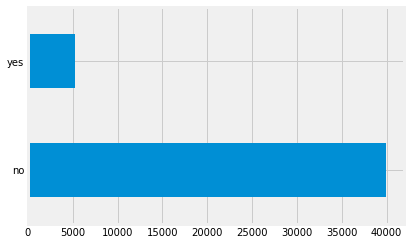

```python
display(bank_df['Target'].value_counts())
bank_df['Target'].value_counts()[:20].plot(kind='barh')
```

#### Observation 4 - Distribution of target variable

Out of 45211 cases, only 5289 (=11.69%) are the cases where the client has subscribed to the term deposit.

```python
# Replace values in some of the categorical columns
replace_values = {'education': {'unknown': -1, 'primary': 1, 'secondary': 2, 'tertiary': 3}, 'Target': {'no': 0, 'yes': 1},
                  'default': {'no': 0, 'yes': 1}, 'housing': {'no': 0, 'yes': 1}, 'loan': {'no': 0, 'yes': 1},
                  'month': {'jan': 1, 'feb': 2, 'mar': 3, 'apr': 4, 'may': 5, 'jun': 6,
                            'jul': 7, 'aug': 8, 'sep': 9, 'oct': 10, 'nov': 11, 'dec': 12}}

bank_df = bank_df.replace(replace_values)
```

```python
# Convert columns to categorical types
columns.extend(['day'])
for cols in columns:
    bank_df[cols] = bank_df[cols].astype('category')
```

```python
 # Functions that will help us with EDA plot
def odp_plots(df, col):
    f,(ax1, ax2, ax3) = plt.subplots(1, 3, figsize = (15, 7.2))

    # Boxplot to check outliers
    sns.boxplot(x = col, data = df, ax = ax1, orient = 'v', color = 'darkslategrey')

    # Distribution plot with outliers
    sns.distplot(df[col], ax = ax2, color = 'teal', fit = norm).set_title(f'Distribution of {col} with outliers')

    # Removing outliers, but in a new dataframe
    upperbound, lowerbound = np.percentile(df[col], [1, 99])
    y = pd.DataFrame(np.clip(df[col], upperbound, lowerbound))

    # Distribution plot without outliers
    sns.distplot(y[col], ax = ax3, color = 'tab:orange', fit = norm).set_title(f'Distribution of {col} without outliers')

    kwargs = {'fontsize':14, 'color':'black'}
    ax1.set_title(col + ' Boxplot Analysis', **kwargs)
    ax1.set_xlabel('Box', **kwargs)
    ax1.set_ylabel(col + ' Values', **kwargs)

    return plt.show()

def target_plot(df, col, target = 'Target'):
    fig = plt.figure(figsize = (15, 7.2))
    # Distribution for 'Target' -- didn't subscribed, considering outliers
    ax = fig.add_subplot(121)
    sns.distplot(df[(df[target] == 0)][col], color = 'c',
                 ax = ax).set_title(f'{col.capitalize()} for Term Desposit - Didn\'t subscribed')

    # Distribution for 'Target' -- Subscribed, considering outliers
    ax= fig.add_subplot(122)
    sns.distplot(df[(df[target] == 1)][col], color = 'b',
             ax = ax).set_title(f'{col.capitalize()} for Term Desposit - Subscribed')
    return plt.show()

def target_count(df, col1, col2):
    fig = plt.figure(figsize = (15, 7.2))
    ax = fig.add_subplot(121)
    sns.countplot(x = col1, data = df, palette = ['tab:blue', 'tab:cyan'], ax = ax, orient = 'v',
                  hue = 'Target').set_title(col1.capitalize() +' count plot by Target',
                                                                      fontsize = 13)
    plt.legend(labels = ['Didn\'t Subcribed', 'Subcribed'])
    plt.xticks(rotation = 90)

    ax = fig.add_subplot(122)
    sns.countplot(x = col2, data = df, palette = ['tab:blue', 'tab:cyan'], ax = ax, orient = 'v',
                  hue = 'Target').set_title(col2.capitalize() +' coount plot by Target',
                                                                      fontsize = 13)
    plt.legend(labels = ['Didn\'t Subcribed', 'Subcribed'])
    plt.xticks(rotation = 90)
    return plt.show()
```

## Univariate and Bivariate Visualization

Looking at one feature at a time to understand how are the values distributed, checking outliers, checking relation of the column with Target column (bi).

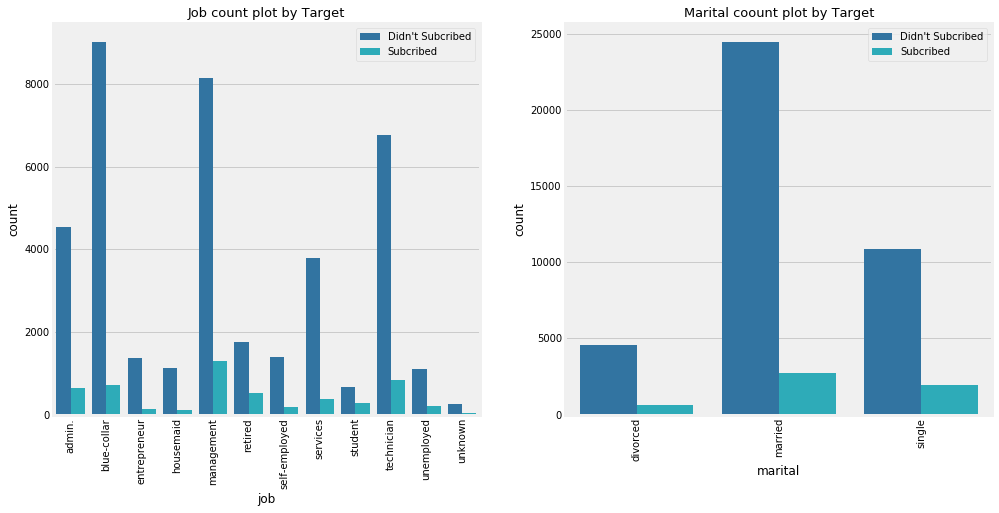

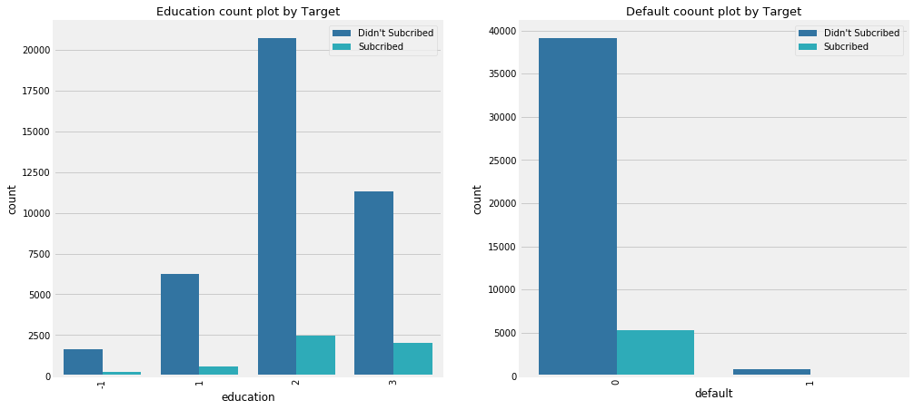

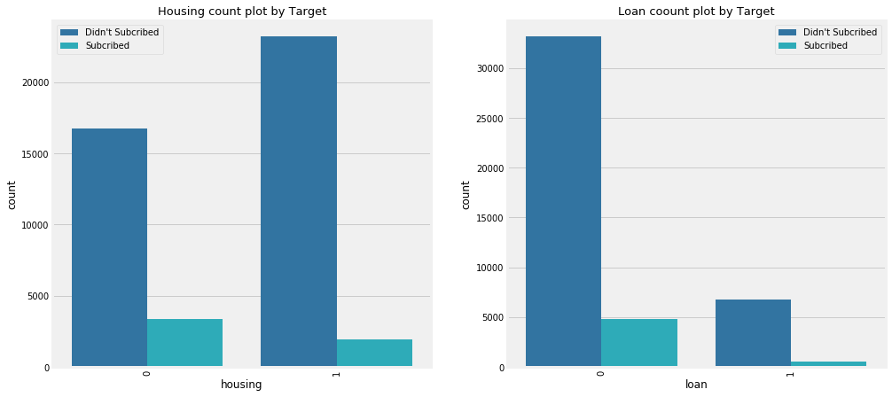

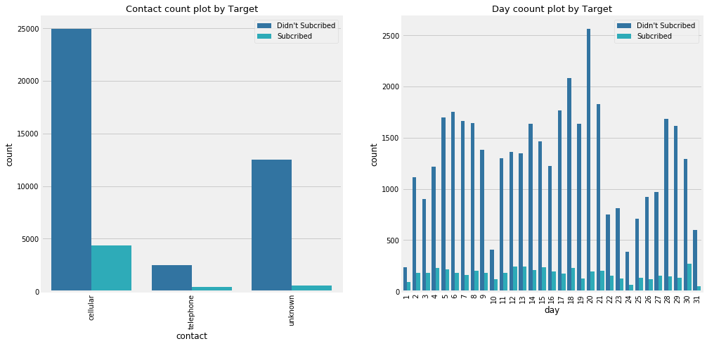

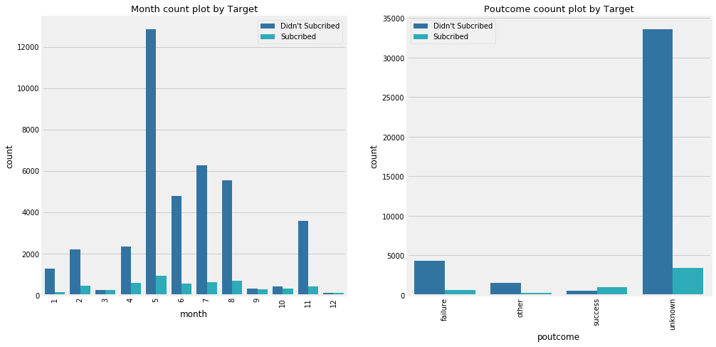

```python
# Subscribe and didn't subscribe for categorical columns
target_count(bank_df, 'job', 'marital')
target_count(bank_df, 'education', 'default')
target_count(bank_df, 'housing', 'loan')
target_count(bank_df, 'contact', 'day')
target_count(bank_df, 'month', 'poutcome')
```

### Check outlier and distribution for numerical columns and also plot it's relation with target variable

```
Age column --------------------------------------------------------------------------------------------------------------
```

|  | age | job | marital | education | default | balance | housing | loan | contact | day | month | duration | campaign | pdays | previous | poutcome | Target |
| --- | --- | --- | --- | --- | --- | --- | --- | --- | --- | --- | --- | --- | --- | --- | --- | --- | --- |
| 29158 | 83 | retired | married | 1 | 0 | 425 | 0 | 0 | telephone | 2 | 2 | 912 | 1 | -1 | 0 | unknown | 0 |
| 29261 | 75 | retired | divorced | 1 | 0 | 46 | 0 | 0 | cellular | 2 | 2 | 294 | 1 | -1 | 0 | unknown | 0 |
| 29263 | 75 | retired | married | 1 | 0 | 3324 | 0 | 0 | cellular | 2 | 2 | 149 | 1 | -1 | 0 | unknown | 0 |
| 29322 | 83 | retired | married | 3 | 0 | 6236 | 0 | 0 | cellular | 2 | 2 | 283 | 2 | -1 | 0 | unknown | 0 |
| 29865 | 75 | retired | divorced | 1 | 0 | 3881 | 1 | 0 | cellular | 4 | 2 | 136 | 3 | -1 | 0 | unknown | 1 |

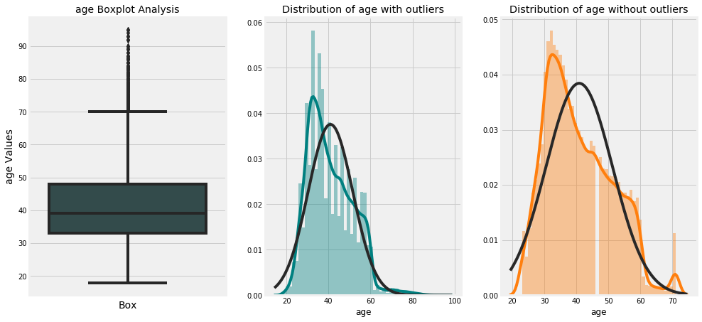

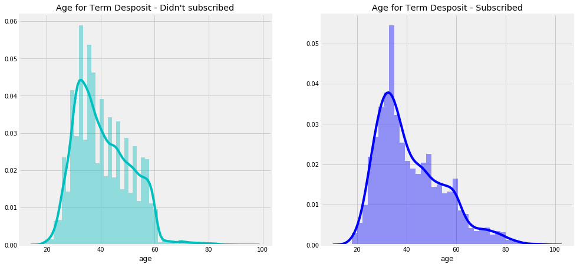

```python
# Outlier, distribution for 'age' column
Q3 = bank_df['age'].quantile(0.75)
Q1 = bank_df['age'].quantile(0.25)
IQR = Q3 - Q1

print('Age column', '--'*55)
display(bank_df.loc[(bank_df['age'] < (Q1 - 1.5 * IQR)) | (bank_df['age'] > (Q3 + 1.5 * IQR))].head())

odp_plots(bank_df, 'age')

# Distribution of 'age' by 'Target'
target_plot(bank_df, 'age')
```

```
Balance column --------------------------------------------------------------------------------------------------------------
```

|  | age | job | marital | education | default | balance | housing | loan | contact | day | month | duration | campaign | pdays | previous | poutcome | Target |
| --- | --- | --- | --- | --- | --- | --- | --- | --- | --- | --- | --- | --- | --- | --- | --- | --- | --- |
| 34 | 51 | management | married | 3 | 0 | 10635 | 1 | 0 | unknown | 5 | 5 | 336 | 1 | -1 | 0 | unknown | 0 |
| 65 | 51 | management | married | 3 | 0 | 6530 | 1 | 0 | unknown | 5 | 5 | 91 | 1 | -1 | 0 | unknown | 0 |
| 69 | 35 | blue-collar | single | 2 | 0 | 12223 | 1 | 1 | unknown | 5 | 5 | 177 | 1 | -1 | 0 | unknown | 0 |
| 70 | 57 | blue-collar | married | 2 | 0 | 5935 | 1 | 1 | unknown | 5 | 5 | 258 | 1 | -1 | 0 | unknown | 0 |
| 186 | 40 | services | divorced | -1 | 0 | 4384 | 1 | 0 | unknown | 5 | 5 | 315 | 1 | -1 | 0 | unknown | 0 |

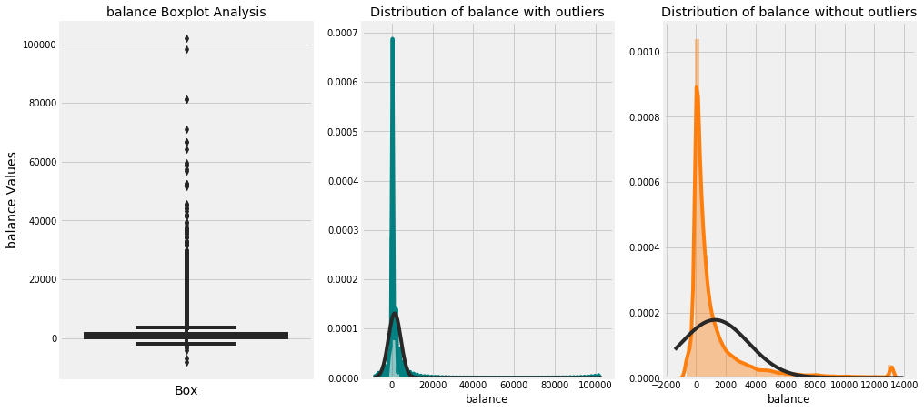

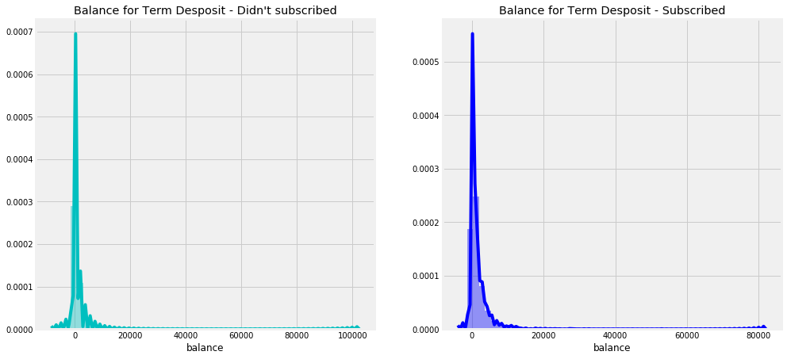

```python
# Outlier, distribution for 'balance' column
Q3 = bank_df['balance'].quantile(0.75)
Q1 = bank_df['balance'].quantile(0.25)
IQR = Q3 - Q1
print('Balance column', '--'*55)
display(bank_df.loc[(bank_df['balance'] < (Q1 - 1.5 * IQR)) | (bank_df['balance'] > (Q3 + 1.5 * IQR))].head())

odp_plots(bank_df, 'balance')

# Distribution of 'balance' by 'Target'
target_plot(bank_df, 'balance')
```

```
Duration column ------------------------------------------------------------------------------------------------------------
```

|  | age | job | marital | education | default | balance | housing | loan | contact | day | month | duration | campaign | pdays | previous | poutcome | Target |
| --- | --- | --- | --- | --- | --- | --- | --- | --- | --- | --- | --- | --- | --- | --- | --- | --- | --- |
| 37 | 53 | technician | married | 2 | 0 | -3 | 0 | 0 | unknown | 5 | 5 | 1666 | 1 | -1 | 0 | unknown | 0 |
| 43 | 54 | retired | married | 2 | 0 | 529 | 1 | 0 | unknown | 5 | 5 | 1492 | 1 | -1 | 0 | unknown | 0 |
| 53 | 42 | admin. | single | 2 | 0 | -76 | 1 | 0 | unknown | 5 | 5 | 787 | 1 | -1 | 0 | unknown | 0 |
| 59 | 46 | services | married | 1 | 0 | 179 | 1 | 0 | unknown | 5 | 5 | 1778 | 1 | -1 | 0 | unknown | 0 |
| 61 | 53 | technician | divorced | 2 | 0 | 989 | 1 | 0 | unknown | 5 | 5 | 812 | 1 | -1 | 0 | unknown | 0 |

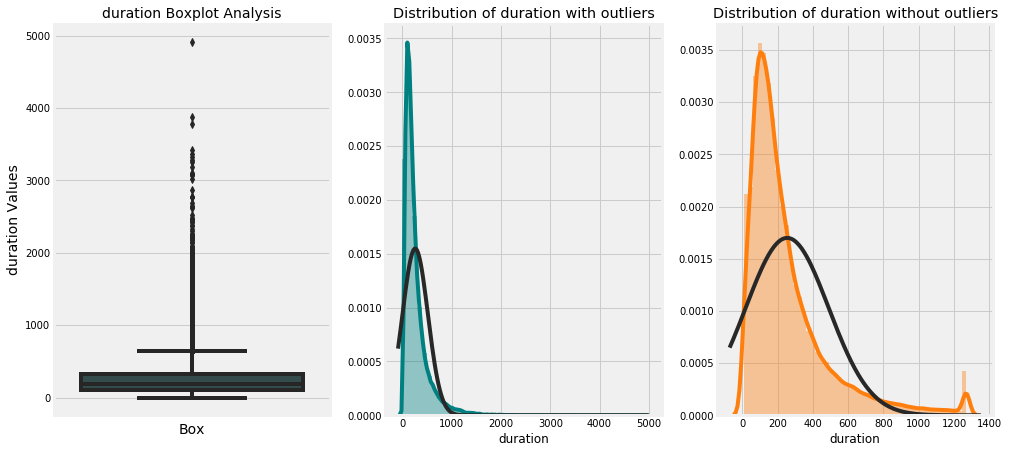

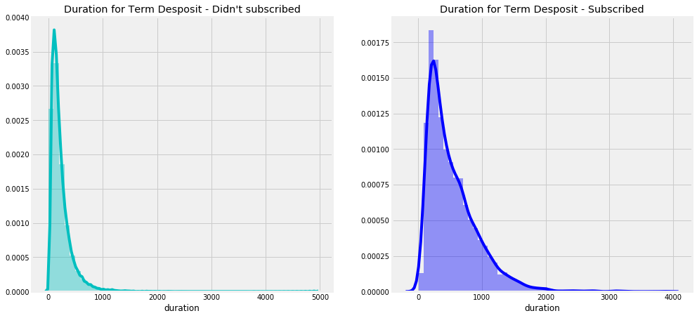

```python
# Outlier, distribution for 'duration' column
Q3 = bank_df['duration'].quantile(0.75)
Q1 = bank_df['duration'].quantile(0.25)
IQR = Q3 - Q1

print('Duration column', '--'*54)
display(bank_df.loc[(bank_df['duration'] < (Q1 - 1.5 * IQR)) | (bank_df['duration'] > (Q3 + 1.5 * IQR))].head())

odp_plots(bank_df, 'duration')

# Distribution of 'duration' by 'Target'
target_plot(bank_df, 'duration')
```

```
Campaign column ------------------------------------------------------------------------------------------------------------
```

|  | age | job | marital | education | default | balance | housing | loan | contact | day | month | duration | campaign | pdays | previous | poutcome | Target |
| --- | --- | --- | --- | --- | --- | --- | --- | --- | --- | --- | --- | --- | --- | --- | --- | --- | --- |
| 758 | 59 | services | married | 2 | 0 | 307 | 1 | 1 | unknown | 6 | 5 | 250 | 7 | -1 | 0 | unknown | 0 |
| 780 | 30 | admin. | married | 2 | 0 | 4 | 0 | 0 | unknown | 7 | 5 | 172 | 8 | -1 | 0 | unknown | 0 |
| 906 | 27 | services | single | 2 | 0 | 0 | 1 | 0 | unknown | 7 | 5 | 388 | 7 | -1 | 0 | unknown | 0 |
| 1103 | 52 | technician | married | -1 | 0 | 133 | 1 | 0 | unknown | 7 | 5 | 253 | 8 | -1 | 0 | unknown | 0 |
| 1105 | 43 | admin. | married | 3 | 0 | 1924 | 1 | 0 | unknown | 7 | 5 | 244 | 7 | -1 | 0 | unknown | 0 |

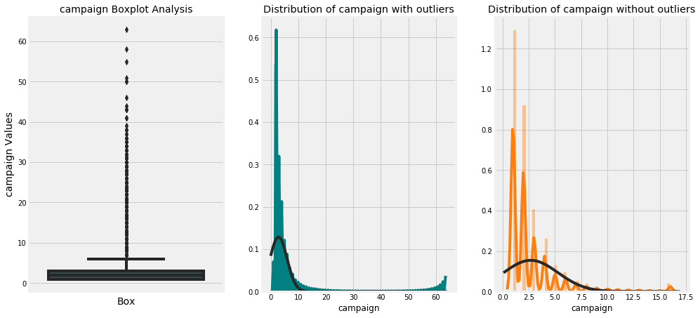

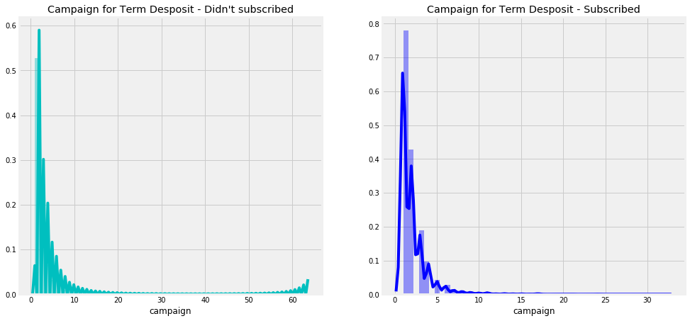

```python
# Outlier, distribution for 'campaign' column
Q3 = bank_df['campaign'].quantile(0.75)
Q1 = bank_df['campaign'].quantile(0.25)
IQR = Q3 - Q1

print('Campaign column', '--'*54)
display(bank_df.loc[(bank_df['campaign'] < (Q1 - 1.5 * IQR)) | (bank_df['campaign'] > (Q3 + 1.5 * IQR))].head())

odp_plots(bank_df, 'campaign')

# Distribution of 'campaign' by 'Target'
target_plot(bank_df, 'campaign')
```

```
Pdays column --------------------------------------------------------------------------------------------------------------
```

|  | age | job | marital | education | default | balance | housing | loan | contact | day | month | duration | campaign | pdays | previous | poutcome | Target |
| --- | --- | --- | --- | --- | --- | --- | --- | --- | --- | --- | --- | --- | --- | --- | --- | --- | --- |
| 24060 | 33 | admin. | married | 3 | 0 | 882 | 0 | 0 | telephone | 21 | 10 | 39 | 1 | 151 | 3 | failure | 0 |
| 24062 | 42 | admin. | single | 2 | 0 | -247 | 1 | 1 | telephone | 21 | 10 | 519 | 1 | 166 | 1 | other | 1 |
| 24064 | 33 | services | married | 2 | 0 | 3444 | 1 | 0 | telephone | 21 | 10 | 144 | 1 | 91 | 4 | failure | 1 |
| 24072 | 36 | management | married | 3 | 0 | 2415 | 1 | 0 | telephone | 22 | 10 | 73 | 1 | 86 | 4 | other | 0 |
| 24077 | 36 | management | married | 3 | 0 | 0 | 1 | 0 | telephone | 23 | 10 | 140 | 1 | 143 | 3 | failure | 1 |

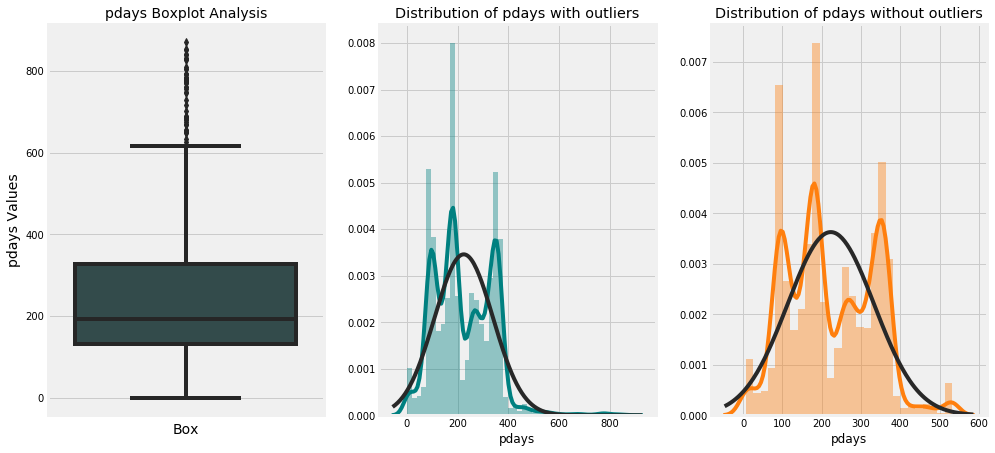

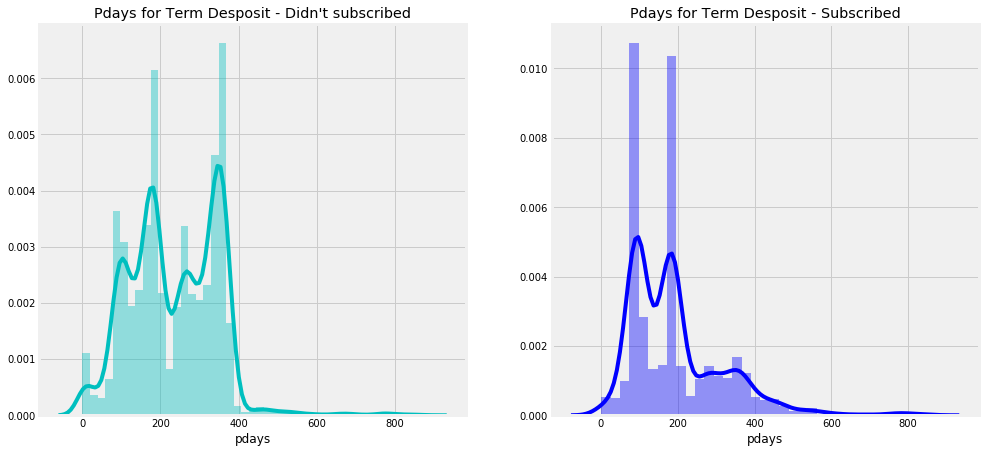

```python
# Outlier, distribution for 'pdays' column
Q3 = bank_df['pdays'].quantile(0.75)
Q1 = bank_df['pdays'].quantile(0.25)
IQR = Q3 - Q1

print('Pdays column', '--'*55)
display(bank_df.loc[(bank_df['pdays'] < (Q1 - 1.5 * IQR)) | (bank_df['pdays'] > (Q3 + 1.5 * IQR))].head())

# Check outlier in 'pdays', not considering -1
pdays = bank_df.loc[bank_df['pdays'] > 0, ['pdays', 'Target']]
pdays = pd.DataFrame(pdays, columns = ['pdays', 'Target'])
odp_plots(pdays, 'pdays')

# Distribution of 'pdays' by 'Target', not considering -1
target_plot(pdays, 'pdays')
```

```
Previous column ------------------------------------------------------------------------------------------------------------
```

|  | age | job | marital | education | default | balance | housing | loan | contact | day | month | duration | campaign | pdays | previous | poutcome | Target |
| --- | --- | --- | --- | --- | --- | --- | --- | --- | --- | --- | --- | --- | --- | --- | --- | --- | --- |
| 24060 | 33 | admin. | married | 3 | 0 | 882 | 0 | 0 | telephone | 21 | 10 | 39 | 1 | 151 | 3 | failure | 0 |
| 24062 | 42 | admin. | single | 2 | 0 | -247 | 1 | 1 | telephone | 21 | 10 | 519 | 1 | 166 | 1 | other | 1 |
| 24064 | 33 | services | married | 2 | 0 | 3444 | 1 | 0 | telephone | 21 | 10 | 144 | 1 | 91 | 4 | failure | 1 |
| 24072 | 36 | management | married | 3 | 0 | 2415 | 1 | 0 | telephone | 22 | 10 | 73 | 1 | 86 | 4 | other | 0 |
| 24077 | 36 | management | married | 3 | 0 | 0 | 1 | 0 | telephone | 23 | 10 | 140 | 1 | 143 | 3 | failure | 1 |

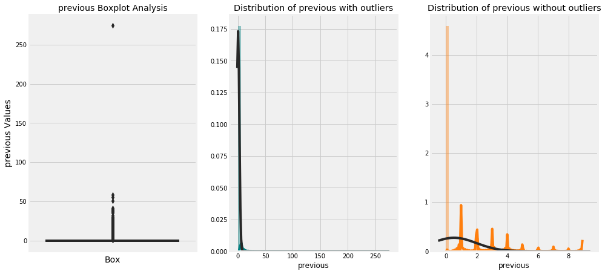

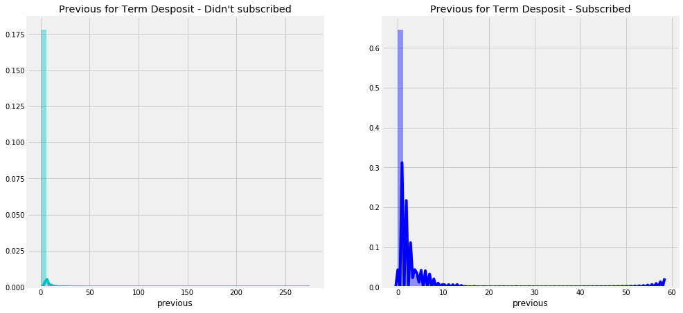

```python
# Outlier, distribution and probability plot for 'previous' column
Q3 = bank_df['previous'].quantile(0.75)
Q1 = bank_df['previous'].quantile(0.25)
IQR = Q3 - Q1

print('Previous column', '--'*54)
display(bank_df.loc[(bank_df['previous'] < (Q1 - 1.5 * IQR)) | (bank_df['previous'] > (Q3 + 1.5 * IQR))].head())

odp_plots(bank_df, 'previous')

# Distribution of 'previous' by 'Target'
target_plot(bank_df, 'previous')
```

### Print categorical and numerical columns list, remove outliers with upper and lower percentile values being 99 and 1, respectively and get dummies

```python
print('Categorical Columns: \n{}'.format(list(bank_df.select_dtypes('category').columns)))
print('\nNumerical Columns: \n{}'.format(list(bank_df.select_dtypes(exclude = 'category').columns)))
```

```
Categorical Columns:
['job', 'marital', 'education', 'default', 'housing', 'loan', 'contact', 'day', 'month', 'poutcome', 'Target']

Numerical Columns:
['age', 'balance', 'duration', 'campaign', 'pdays', 'previous']
```

```python
# Removing outliers with upper and lower percentile values being 99 and 1, respectively
bank_nulls = bank_df.copy(deep = True)
columns = ['age', 'balance', 'duration', 'campaign', 'pdays', 'previous']

for col in columns:
    upper_lim = np.percentile(bank_nulls[col].values, 99)
    lower_lim = np.percentile(bank_nulls[col].values, 1)
    bank_nulls.loc[(bank_nulls[col] > upper_lim), col] = np.nan
    bank_nulls.loc[(bank_nulls[col] < lower_lim), col] = np.nan

print('Column for which outliers where removed with upper and lower percentile values: \n', columns)
```

```
Column for which outliers where removed with upper and lower percentile values:
 ['age', 'balance', 'duration', 'campaign', 'pdays', 'previous']
```

```python
# pd.get_dummies
cols_to_transform = ['job', 'marital', 'contact', 'poutcome']
bank_nulls = pd.get_dummies(bank_nulls, columns = cols_to_transform) #, drop_first = True)

print('Got dummies for \n', cols_to_transform)
bank_nulls.info()
```

```
Got dummies for
 ['job', 'marital', 'contact', 'poutcome']
<class 'pandas.core.frame.DataFrame'>
RangeIndex: 45211 entries, 0 to 45210
Data columns (total 35 columns):
age                  44473 non-null float64
education            45211 non-null category
default              45211 non-null category
balance              44308 non-null float64
housing              45211 non-null category
loan                 45211 non-null category
day                  45211 non-null category
month                45211 non-null category
duration             44341 non-null float64
campaign             44760 non-null float64
pdays                44826 non-null float64
previous             44758 non-null float64
Target               45211 non-null category
job_admin.           45211 non-null uint8
job_blue-collar      45211 non-null uint8
job_entrepreneur     45211 non-null uint8
job_housemaid        45211 non-null uint8
job_management       45211 non-null uint8
job_retired          45211 non-null uint8
job_self-employed    45211 non-null uint8
job_services         45211 non-null uint8
job_student          45211 non-null uint8
job_technician       45211 non-null uint8
job_unemployed       45211 non-null uint8
job_unknown          45211 non-null uint8
marital_divorced     45211 non-null uint8
marital_married      45211 non-null uint8
marital_single       45211 non-null uint8
contact_cellular     45211 non-null uint8
contact_telephone    45211 non-null uint8
contact_unknown      45211 non-null uint8
poutcome_failure     45211 non-null uint8
poutcome_other       45211 non-null uint8
poutcome_success     45211 non-null uint8
poutcome_unknown     45211 non-null uint8
dtypes: category(7), float64(6), uint8(22)
memory usage: 3.3 MB
```

```python
# Convert 'astype' of categorical columns to integer for getting it ready for MICE
columns = ['education', 'default', 'housing', 'loan', 'day', 'month', 'Target']
for col in columns:
    bank_nulls[col] = bank_nulls[col].astype('float')
```

### Use MICE imputer to handled outliers that were filled with `np.nan` in the earlier step

```python
# start the MICE training
bank_imputed = mice(bank_nulls.values)
bank_imputed = pd.DataFrame(bank_imputed, columns = bank_nulls.columns)

display(bank_df.describe(include = 'all').T, bank_imputed.describe(include = 'all').T)
```

|  | count | unique | top | freq | mean | std | min | 25% | 50% | 75% | max |
| --- | --- | --- | --- | --- | --- | --- | --- | --- | --- | --- | --- |
| age | 45211 | NaN | NaN | NaN | 40.9362 | 10.6188 | 18 | 33 | 39 | 48 | 95 |
| job | 45211 | 12 | blue-collar | 9732 | NaN | NaN | NaN | NaN | NaN | NaN | NaN |
| marital | 45211 | 3 | married | 27214 | NaN | NaN | NaN | NaN | NaN | NaN | NaN |
| education | 45211 | 4 | 2 | 23202 | NaN | NaN | NaN | NaN | NaN | NaN | NaN |
| default | 45211 | 2 | 0 | 44396 | NaN | NaN | NaN | NaN | NaN | NaN | NaN |
| balance | 45211 | NaN | NaN | NaN | 1362.27 | 3044.77 | -8019 | 72 | 448 | 1428 | 102127 |
| housing | 45211 | 2 | 1 | 25130 | NaN | NaN | NaN | NaN | NaN | NaN | NaN |
| loan | 45211 | 2 | 0 | 37967 | NaN | NaN | NaN | NaN | NaN | NaN | NaN |
| contact | 45211 | 3 | cellular | 29285 | NaN | NaN | NaN | NaN | NaN | NaN | NaN |
| day | 45211 | 31 | 20 | 2752 | NaN | NaN | NaN | NaN | NaN | NaN | NaN |
| month | 45211 | 12 | 5 | 13766 | NaN | NaN | NaN | NaN | NaN | NaN | NaN |
| duration | 45211 | NaN | NaN | NaN | 258.163 | 257.528 | 0 | 103 | 180 | 319 | 4918 |
| campaign | 45211 | NaN | NaN | NaN | 2.76384 | 3.09802 | 1 | 1 | 2 | 3 | 63 |
| pdays | 45211 | NaN | NaN | NaN | 40.1978 | 100.129 | -1 | -1 | -1 | -1 | 871 |
| previous | 45211 | NaN | NaN | NaN | 0.580323 | 2.30344 | 0 | 0 | 0 | 0 | 275 |
| poutcome | 45211 | 4 | unknown | 36959 | NaN | NaN | NaN | NaN | NaN | NaN | NaN |
| Target | 45211 | 2 | 0 | 39922 | NaN | NaN | NaN | NaN | NaN | NaN | NaN |

|  | count | mean | std | min | 25% | 50% | 75% | max |
| --- | --- | --- | --- | --- | --- | --- | --- | --- |
| age | 45211.0 | 40.836870 | 10.073693 | 23.000000 | 33.0 | 39.0 | 48.0 | 71.743918 |
| education | 45211.0 | 2.019442 | 0.902795 | -1.000000 | 2.0 | 2.0 | 3.0 | 3.000000 |
| default | 45211.0 | 0.018027 | 0.133049 | 0.000000 | 0.0 | 0.0 | 0.0 | 1.000000 |
| balance | 45211.0 | 1174.931966 | 1898.534836 | -812.500971 | 81.0 | 467.0 | 1402.0 | 13164.000000 |
| housing | 45211.0 | 0.555838 | 0.496878 | 0.000000 | 0.0 | 1.0 | 1.0 | 1.000000 |
| loan | 45211.0 | 0.160226 | 0.366820 | 0.000000 | 0.0 | 0.0 | 0.0 | 1.000000 |
| day | 45211.0 | 15.806419 | 8.322476 | 1.000000 | 8.0 | 16.0 | 21.0 | 31.000000 |
| month | 45211.0 | 6.144655 | 2.408034 | 1.000000 | 5.0 | 6.0 | 8.0 | 12.000000 |
| duration | 45211.0 | 247.428930 | 211.290370 | 11.000000 | 106.0 | 183.0 | 316.0 | 1269.000000 |
| campaign | 45211.0 | 2.562222 | 2.214906 | 1.000000 | 1.0 | 2.0 | 3.0 | 16.000000 |
| pdays | 45211.0 | 37.922341 | 92.399488 | -47.831693 | -1.0 | -1.0 | -1.0 | 370.000000 |
| previous | 45211.0 | 0.461333 | 1.208702 | 0.000000 | 0.0 | 0.0 | 0.0 | 8.000000 |
| Target | 45211.0 | 0.116985 | 0.321406 | 0.000000 | 0.0 | 0.0 | 0.0 | 1.000000 |
| job_admin. | 45211.0 | 0.114375 | 0.318269 | 0.000000 | 0.0 | 0.0 | 0.0 | 1.000000 |
| job_blue-collar | 45211.0 | 0.215257 | 0.411005 | 0.000000 | 0.0 | 0.0 | 0.0 | 1.000000 |
| job_entrepreneur | 45211.0 | 0.032890 | 0.178351 | 0.000000 | 0.0 | 0.0 | 0.0 | 1.000000 |
| job_housemaid | 45211.0 | 0.027427 | 0.163326 | 0.000000 | 0.0 | 0.0 | 0.0 | 1.000000 |
| job_management | 45211.0 | 0.209197 | 0.406740 | 0.000000 | 0.0 | 0.0 | 0.0 | 1.000000 |
| job_retired | 45211.0 | 0.050076 | 0.218105 | 0.000000 | 0.0 | 0.0 | 0.0 | 1.000000 |
| job_self-employed | 45211.0 | 0.034925 | 0.183592 | 0.000000 | 0.0 | 0.0 | 0.0 | 1.000000 |
| job_services | 45211.0 | 0.091880 | 0.288860 | 0.000000 | 0.0 | 0.0 | 0.0 | 1.000000 |
| job_student | 45211.0 | 0.020747 | 0.142538 | 0.000000 | 0.0 | 0.0 | 0.0 | 1.000000 |
| job_technician | 45211.0 | 0.168034 | 0.373901 | 0.000000 | 0.0 | 0.0 | 0.0 | 1.000000 |
| job_unemployed | 45211.0 | 0.028820 | 0.167303 | 0.000000 | 0.0 | 0.0 | 0.0 | 1.000000 |
| job_unknown | 45211.0 | 0.006370 | 0.079559 | 0.000000 | 0.0 | 0.0 | 0.0 | 1.000000 |
| marital_divorced | 45211.0 | 0.115171 | 0.319232 | 0.000000 | 0.0 | 0.0 | 0.0 | 1.000000 |
| marital_married | 45211.0 | 0.601933 | 0.489505 | 0.000000 | 0.0 | 1.0 | 1.0 | 1.000000 |
| marital_single | 45211.0 | 0.282896 | 0.450411 | 0.000000 | 0.0 | 0.0 | 1.0 | 1.000000 |
| contact_cellular | 45211.0 | 0.647741 | 0.477680 | 0.000000 | 0.0 | 1.0 | 1.0 | 1.000000 |
| contact_telephone | 45211.0 | 0.064276 | 0.245247 | 0.000000 | 0.0 | 0.0 | 0.0 | 1.000000 |
| contact_unknown | 45211.0 | 0.287983 | 0.452828 | 0.000000 | 0.0 | 0.0 | 1.0 | 1.000000 |
| poutcome_failure | 45211.0 | 0.108403 | 0.310892 | 0.000000 | 0.0 | 0.0 | 0.0 | 1.000000 |
| poutcome_other | 45211.0 | 0.040698 | 0.197592 | 0.000000 | 0.0 | 0.0 | 0.0 | 1.000000 |
| poutcome_success | 45211.0 | 0.033421 | 0.179735 | 0.000000 | 0.0 | 0.0 | 0.0 | 1.000000 |
| poutcome_unknown | 45211.0 | 0.817478 | 0.386278 | 0.000000 | 1.0 | 1.0 | 1.0 | 1.000000 |

#### Observation 7 - Observation after MICE

| **Column** | **Before MICE** | **After MICE** |
| --- | --- | --- |
| **`age`** | Range of Q1 to Q3 is 33-48. Mean > Median, right (positively) skewed | Range of Q1 to Q3 is unchanged, because of change in min and max values there's a slight reduction is mean, right skewed |
| **`balance`** | Range of Q1 to Q3 is 72-1428. Mean > Median, skewed towards right (positively) | Range of Q1 to Q3 is 81 to 1402, reduction in mean, right skewed |
| **`duration`** | Range of Q1 to Q3 is 103-319. Mean > Median, right (positively) skewed | Range of Q1 to Q3 is 106-316, right skewed |
| **`campaign`** | Range of Q1 to Q3 is 1-3. Mean > Median, right (positively) skewed | Unchanged range and skewness |
| **`pdays`** | 75% of data values are around -1 | Unchanged |
| **`previous`** | 75% of data values are around 0 | Unchanged |

## Multivariate visualization

Checking relationship between two or more variables. Includes correlation and scatterplot matrix, checking relation between two variables and Target.

### Check scattermatrix

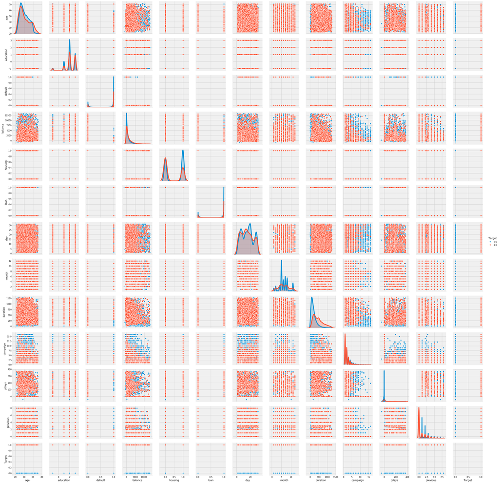

```python
sns.pairplot(bank_imputed[['age', 'education', 'default', 'balance', 'housing', 'loan', 'day', 'month',
                           'duration', 'campaign', 'pdays', 'previous', 'Target']], hue = 'Target')
```

### Correlation matrix

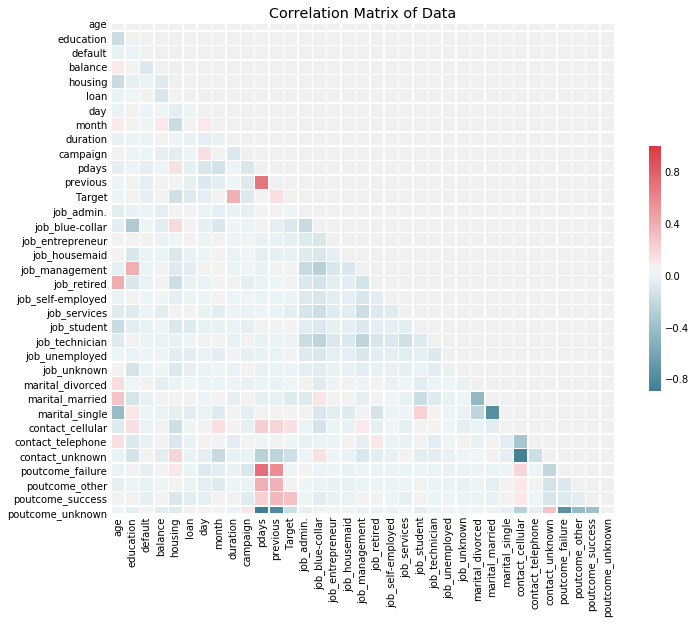

```python
# Correlation matrix for all variables
corr = bank_imputed.corr()

mask = np.zeros_like(corr, dtype = np.bool)
mask[np.triu_indices_from(mask)] = True

f, ax = plt.subplots(figsize = (11, 9))

cmap = sns.diverging_palette(220, 10, as_cmap = True)

sns.heatmap(corr, mask = mask, cmap = cmap, square = True, linewidths = .5, cbar_kws = {"shrink": .5})#, annot = True)
ax.set_title('Correlation Matrix of Data')
```

```python
# Filter for correlation value greater than 0.8
sort = corr.abs().unstack()
sort = sort.sort_values(kind = "quicksort", ascending = False)
sort[(sort > 0.8) & (sort < 1)]
```

```
pdays             poutcome_unknown    0.891235
poutcome_unknown  pdays               0.891235
contact_unknown   contact_cellular    0.862398
contact_cellular  contact_unknown     0.862398
previous          poutcome_unknown    0.806952
poutcome_unknown  previous            0.806952
dtype: float64
```

```python
# Absolute correlation of independent variables with 'Target' i.e. the target variable
absCorrwithDep = []
allVars = bank_imputed.drop('Target', axis = 1).columns

for var in allVars:
    absCorrwithDep.append(abs(bank_imputed['Target'].corr(bank_imputed[var])))

display(pd.DataFrame([allVars, absCorrwithDep], index = ['Variable', 'Correlation']).T.\
        sort_values('Correlation', ascending = False))
```

|  | Variable | Correlation |
| --- | --- | --- |
| 8 | duration | 0.398107 |
| 32 | poutcome_success | 0.306788 |
| 33 | poutcome_unknown | 0.167051 |
| 11 | previous | 0.153341 |
| 29 | contact_unknown | 0.150935 |
| 4 | housing | 0.139173 |
| 27 | contact_cellular | 0.135873 |
| 10 | pdays | 0.0865931 |
| 17 | job_retired | 0.0792453 |
| 3 | balance | 0.0769225 |
| 20 | job_student | 0.076897 |
| 9 | campaign | 0.0754512 |
| 13 | job_blue-collar | 0.0720831 |
| 5 | loan | 0.068185 |
| 26 | marital_single | 0.0635258 |
| 25 | marital_married | 0.0602604 |
| 1 | education | 0.0416343 |
| 16 | job_management | 0.0329188 |
| 31 | poutcome_other | 0.031955 |
| 6 | day | 0.0283478 |
| 19 | job_services | 0.0278639 |
| 2 | default | 0.022419 |
| 22 | job_unemployed | 0.0203899 |
| 14 | job_entrepreneur | 0.0196623 |
| 7 | month | 0.018717 |
| 15 | job_housemaid | 0.0151949 |
| 28 | contact_telephone | 0.0140425 |
| 0 | age | 0.0134745 |
| 30 | poutcome_failure | 0.00988545 |
| 21 | job_technician | 0.00896982 |
| 12 | job_admin. | 0.00563747 |
| 24 | marital_divorced | 0.00277237 |
| 18 | job_self-employed | 0.000855031 |
| 23 | job_unknown | 0.000266748 |

#### Observation 9 - Correlation Matrix

- `poutcome_unknown` and `pdays`; `contact_unknown` and `contact_cellular`; `poutcome_unknown` and `previous`; `marital_married` and `marital_single`; `poutcome_unknown` and `poutcome_failure`; `pdays` and `poutcome_failure`; `previous` and `pdays`; `poutcome_failure` and `previous` columns are correlated with each other.
- `duration`, `poutcome_success`, `poutcome_unknown` and `previous` are few columns which have a relatively strong correlation with `Target` column.

### Creating age groups and check relation with balance and target; also with campaign and target

```python
# Creating age groups
bank_imputed.loc[(bank_imputed['age'] < 30), 'age_group'] = 20
bank_imputed.loc[(bank_imputed['age'] >= 30) & (bank_imputed['age'] < 40), 'age_group'] = 30
bank_imputed.loc[(bank_imputed['age'] >= 40) & (bank_imputed['age'] < 50), 'age_group'] = 40
bank_imputed.loc[(bank_imputed['age'] >= 50) & (bank_imputed['age'] < 60), 'age_group'] = 50
bank_imputed.loc[(bank_imputed['age'] >= 60), 'age_group'] = 60
```

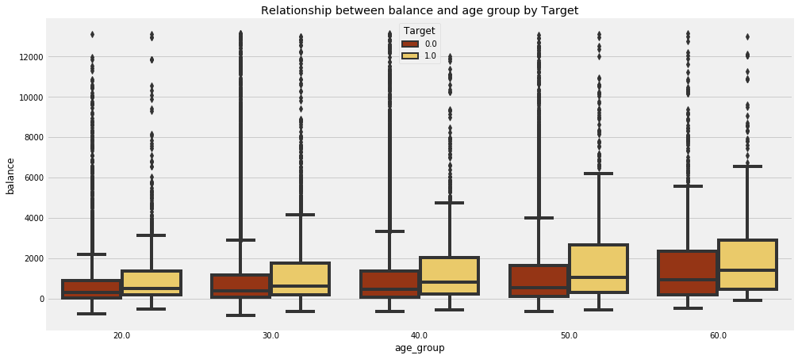

```python
# Check relationship between balance and age group by Target
fig = plt.figure(figsize = (15, 7.2))
ax = sns.boxplot(x = 'age_group', y = 'balance', hue = 'Target', palette = 'afmhot', data = bank_imputed)
ax.set_title('Relationship between balance and age group by Target')
```

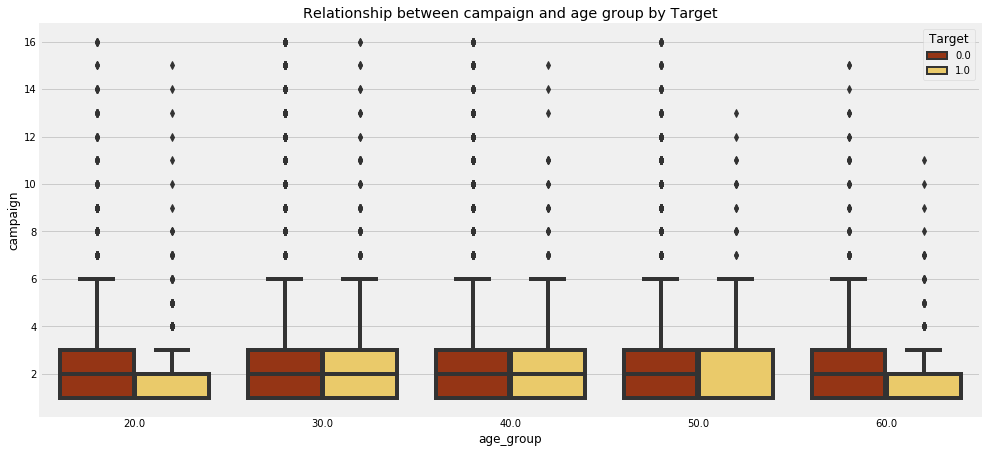

```python
# Check relationship between campaign and age group by Target
fig = plt.figure(figsize = (15, 7.2))
ax = sns.boxplot(x = 'age_group', y = 'campaign', hue = 'Target', palette = 'afmhot', data = bank_imputed)
ax.set_title('Relationship between campaign and age group by Target')
```

## Modelling

- Create a baseline model
- Use different classification models (Logistic, K-NN and Naïve Bayes) to predict will the client subscribe to term deposit.
- Training and making predictions using an Ensemble Model.

### Dummy Classifier -- Baseline Model

```python
# Separating dependent and independent variables
X = bank_imputed.drop(['Target'], axis = 1)
y = bank_imputed['Target']

# Splitting the data into training and test set in the ratio of 70:30 respectively
X_train, X_test, y_train, y_test = train_test_split(X, y, test_size = 0.3, random_state = 44)

dummy = DummyClassifier(strategy = 'most_frequent', random_state = 44)
dummy.fit(X_train, y_train)
y_pred = dummy.predict(X_test)

accuracy_ = accuracy_score(y_test, y_pred)
pre_s = precision_score(y_test, y_pred, average = 'binary', pos_label = 1)
re_s = recall_score(y_test, y_pred, average = 'binary', pos_label = 1)
f1_s = f1_score(y_test, y_pred, average = 'binary', pos_label = 1)

pre_m = precision_score(y_test, y_pred, average = 'macro')
re_m = recall_score(y_test, y_pred, average = 'macro')
f1_m = f1_score(y_test, y_pred, average = 'macro')

print('Training Score: ', dummy.score(X_train, y_train).round(3))
print('Test Score: ', dummy.score(X_test, y_test).round(3))

print('Accuracy: ', accuracy_.round(3))
print('Precision Score - Subscribe: ', pre_s.round(3))
print('Recall Score - Subscribe: ', re_s.round(3))
print('f1 Score - Subscribe: ', f1_s.round(3))

print('Precision Score - Macro: ', pre_m.round(3))
print('Recall Score - Macro: ', re_m.round(3))
print('f1 Score - Macro: ', f1_m.round(3))

df = pd.DataFrame([accuracy_.round(3), pre_s.round(3), pre_m.round(3), re_s.round(3),
                   re_m.round(3), f1_s.round(3), f1_m.round(3)], columns = ['Baseline Model']).T
df.columns = ['Accuracy', 'Precision_Subscribe', 'Precision_Macro',
              'Recall_Subscribe', 'Recall_Macro', 'f1_Subscribe', 'f1_Macro']
df
```

```
Training Score:  0.884
Test Score:  0.882
Accuracy:  0.882
Precision Score - Subscribe:  0.0
Recall Score - Subscribe:  0.0
f1 Score - Subscribe:  0.0
Precision Score - Macro:  0.441
Recall Score - Macro:  0.5
f1 Score - Macro:  0.469
```

|  | Accuracy | Precision_Subscribe | Precision_Macro | Recall_Subscribe | Recall_Macro | f1_Subscribe | f1_Macro |
| --- | --- | --- | --- | --- | --- | --- | --- |
| Baseline Model | 0.882 | 0.0 | 0.441 | 0.0 | 0.5 | 0.0 | 0.469 |

```python
# Helper function for making prediction and evaluating scores
def train_and_predict(n_splits, base_model, X, y, name, subscribe = 1, oversampling = False):
    features = X.columns
    X = np.array(X)
    y = np.array(y)

    folds = list(StratifiedKFold(n_splits = n_splits, shuffle = True, random_state = random_state).split(X, y))

    train_pred = np.zeros((X.shape[0], len(base_model)))

    accuracy = []

    precision_subscribe = []
    recall_subscribe = []
    f1_subscribe = []

    precision_macro = []
    recall_macro = []
    f1_macro = []

    for i, clf in enumerate(base_model):
        for j, (train, test) in enumerate(folds):

            # Creating train and test sets
            X_train = X[train]
            y_train = y[train]
            X_test = X[test]
            y_test = y[test]

            if oversampling:
                sm = SMOTE(random_state = random_state, sampling_strategy = 'minority')
                X_train_res, y_train_res = sm.fit_sample(X_train, y_train)

            # fit the model
                clf.fit(X_train_res, y_train_res)

            # Get predictions
                y_true, y_pred = y_test, clf.predict(X_test)

            # Evaluate train and test scores
                train_ = clf.score(X_train_res, y_train_res)
                test_ = clf.score(X_test, y_test)

            else:

            # fit the model
                clf.fit(X_train, y_train)

            # Get predictions
                y_true, y_pred = y_test, clf.predict(X_test)

            # Evaluate train and test scores
                train_ = clf.score(X_train, y_train)
                test_ = clf.score(X_test, y_test)

            # Other scores
            accuracy_ = accuracy_score(y_true, y_pred).round(3)

            precision_b = precision_score(y_true, y_pred, average = 'binary', pos_label = subscribe).round(3)
            recall_b = recall_score(y_true, y_pred, average = 'binary', pos_label = subscribe).round(3)
            f1_b = f1_score(y_true, y_pred, average = 'binary', pos_label = subscribe).round(3)

            precision_m = precision_score(y_true, y_pred, average = 'macro').round(3)
            recall_m = recall_score(y_true, y_pred, average = 'macro').round(3)
            f1_m = f1_score(y_true, y_pred, average = 'macro').round(3)

            print(f'Model- {name.capitalize()} and CV- {j}')
            print('-'*20)
            print('Training Score: {0:.3f}'.format(train_))
            print('Test Score: {0:.3f}'.format(test_))

            print('Accuracy Score: {0:.3f}'.format(accuracy_))

            print('Precision Score - Subscribe: {0:.3f}'.format(precision_b))
            print('Recall Score - Subscribe: {0:.3f}'.format(recall_b))
            print('f1 Score - Subscribe: {0:.3f}'.format(f1_b))

            print('Precision Score - Macro: {0:.3f}'.format(precision_m))
            print('Recall Score - Macro: {0:.3f}'.format(recall_m))
            print('f1 Score - Macro: {0:.3f}'.format(f1_m))
            print('\n')

            ## Appending scores
            accuracy.append(accuracy_)
            precision_subscribe.append(precision_b)
            recall_subscribe.append(recall_b)
            f1_subscribe.append(f1_b)
            precision_macro.append(precision_m)
            recall_macro.append(recall_m)
            f1_macro.append(f1_m)

            # Creating a dataframe of scores
            df = pd.DataFrame([np.mean(accuracy).round(3), np.mean(precision_subscribe).round(3),
                               np.mean(precision_macro).round(3), np.mean(recall_subscribe).round(3),
                               np.mean(recall_macro).round(3), np.mean(f1_subscribe).round(3),
                               np.mean(f1_macro).round(3)], columns = [name]).T
            df.columns = ['Accuracy', 'Precision_Subscribe', 'Precision_Macro',
                          'Recall_Subscribe', 'Recall_Macro', 'f1_Subscribe', 'f1_Macro']

    return df
```

```python
# Separating dependent and independent variables
from sklearn.preprocessing import RobustScaler
X = bank_imputed.drop(['Target'], axis = 1)
y = bank_imputed['Target']

# Applying RobustScaler to make it less prone to outliers
features = X.columns
scaler = RobustScaler()
X = pd.DataFrame(scaler.fit_transform(X), columns = features)

# Scaling the independent variables
Xs = X.apply(zscore)

display(X.shape, Xs.shape, y.shape)
```

```
(45211, 35)
```

```
(45211, 35)
```

```
(45211,)
```

### Logistic Regression, kNN and Naive Bayes

Oversampling the one with better accuracy and recall score for subscribe

#### Logistic Regression

```python
# LR model without hyperparameter tuning
LR = LogisticRegression()
base_model = [LR]
n_splits = 5
df1 = train_and_predict(n_splits, base_model, X, y, 'Logistic Regression Without Hyperparameter Tuning')
df = df.append(df1)
df
```

```
Model- Logistic regression without hyperparameter tuning and CV- 0
--------------------
Training Score: 0.898
Test Score: 0.901
Accuracy Score: 0.901
Precision Score - Subscribe: 0.647
Recall Score - Subscribe: 0.344
f1 Score - Subscribe: 0.449
Precision Score - Macro: 0.782
Recall Score - Macro: 0.660
f1 Score - Macro: 0.697


Model- Logistic regression without hyperparameter tuning and CV- 1
--------------------
Training Score: 0.898
Test Score: 0.900
Accuracy Score: 0.900
Precision Score - Subscribe: 0.643
Recall Score - Subscribe: 0.334
f1 Score - Subscribe: 0.440
Precision Score - Macro: 0.780
Recall Score - Macro: 0.655
f1 Score - Macro: 0.692


Model- Logistic regression without hyperparameter tuning and CV- 2
--------------------
Training Score: 0.900
Test Score: 0.893
Accuracy Score: 0.893
Precision Score - Subscribe: 0.581
Recall Score - Subscribe: 0.318
f1 Score - Subscribe: 0.411
Precision Score - Macro: 0.748
Recall Score - Macro: 0.644
f1 Score - Macro: 0.676


Model- Logistic regression without hyperparameter tuning and CV- 3
```

[output cut: 8 more lines]

```
Recall Score - Macro: 0.645
f1 Score - Macro: 0.681


Model- Logistic regression without hyperparameter tuning and CV- 4
--------------------
Training Score: 0.898
Test Score: 0.897
Accuracy Score: 0.897
Precision Score - Subscribe: 0.622
Recall Score - Subscribe: 0.316
f1 Score - Subscribe: 0.419
Precision Score - Macro: 0.768
Recall Score - Macro: 0.645
f1 Score - Macro: 0.681
```

|  | Accuracy | Precision_Subscribe | Precision_Macro | Recall_Subscribe | Recall_Macro | f1_Subscribe | f1_Macro |
| --- | --- | --- | --- | --- | --- | --- | --- |
| Baseline Model | 0.882 | 0.000 | 0.441 | 0.000 | 0.50 | 0.000 | 0.469 |
| Logistic Regression Without Hyperparameter Tuning | 0.898 | 0.623 | 0.769 | 0.326 | 0.65 | 0.428 | 0.685 |

#### k-Nearest Neighbor Classifier

```python
# KNN Model after scaling the features without hyperparameter tuning
kNN = KNeighborsClassifier()
base_model = [kNN]
n_splits = 5
df1 = train_and_predict(n_splits, base_model, Xs, y, 'k-Nearest Neighbor Scaled Without Hyperparameter Tuning')
df = df.append(df1)
df
```

```
Model- K-nearest neighbor scaled without hyperparameter tuning and CV- 0
--------------------
Training Score: 0.916
Test Score: 0.891
Accuracy Score: 0.891
Precision Score - Subscribe: 0.566
Recall Score - Subscribe: 0.296
f1 Score - Subscribe: 0.389
Precision Score - Macro: 0.739
Recall Score - Macro: 0.633
f1 Score - Macro: 0.664


Model- K-nearest neighbor scaled without hyperparameter tuning and CV- 1
--------------------
Training Score: 0.917
Test Score: 0.892
Accuracy Score: 0.892
Precision Score - Subscribe: 0.569
Recall Score - Subscribe: 0.319
f1 Score - Subscribe: 0.409
Precision Score - Macro: 0.742
Recall Score - Macro: 0.643
f1 Score - Macro: 0.675


Model- K-nearest neighbor scaled without hyperparameter tuning and CV- 2
--------------------
Training Score: 0.917
Test Score: 0.888
Accuracy Score: 0.888
Precision Score - Subscribe: 0.539
Recall Score - Subscribe: 0.279
f1 Score - Subscribe: 0.368
Precision Score - Macro: 0.725
Recall Score - Macro: 0.624
f1 Score - Macro: 0.653


Model- K-nearest neighbor scaled without hyperparameter tuning and CV- 3
```

[output cut: 8 more lines]

```
Recall Score - Macro: 0.631
f1 Score - Macro: 0.663


Model- K-nearest neighbor scaled without hyperparameter tuning and CV- 4
--------------------
Training Score: 0.917
Test Score: 0.891
Accuracy Score: 0.891
Precision Score - Subscribe: 0.560
Recall Score - Subscribe: 0.311
f1 Score - Subscribe: 0.400
Precision Score - Macro: 0.737
Recall Score - Macro: 0.639
f1 Score - Macro: 0.670
```

|  | Accuracy | Precision_Subscribe | Precision_Macro | Recall_Subscribe | Recall_Macro | f1_Subscribe | f1_Macro |
| --- | --- | --- | --- | --- | --- | --- | --- |
| Baseline Model | 0.882 | 0.000 | 0.441 | 0.000 | 0.500 | 0.000 | 0.469 |
| Logistic Regression Without Hyperparameter Tuning | 0.898 | 0.623 | 0.769 | 0.326 | 0.650 | 0.428 | 0.685 |
| k-Nearest Neighbor Scaled Without Hyperparameter Tuning | 0.891 | 0.560 | 0.736 | 0.299 | 0.634 | 0.390 | 0.665 |

```
uniform
```

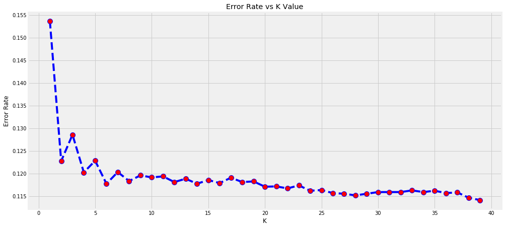

```
distance
```

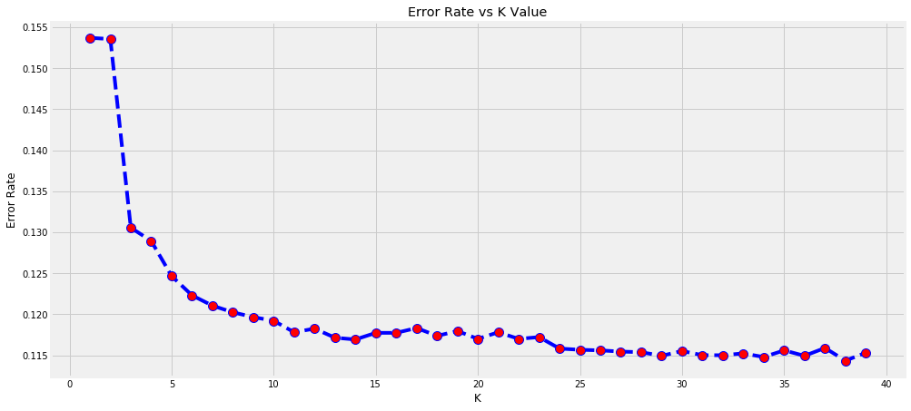

```python
# Choosing a K Value
error_rate = {}
weights = ['uniform', 'distance']
for w in weights:
    print(w)
    rate = []
    for i in range(1, 40):
        knn = KNeighborsClassifier(n_neighbors = i, weights = w)
        knn.fit(X_train, y_train)
        y_pred = knn.predict(X_test)
        rate.append(np.mean(y_pred != y_test))
    plt.figure(figsize = (15, 7.2))
    plt.plot(range(1, 40), rate, color = 'blue', linestyle = 'dashed', marker = 'o',
             markerfacecolor = 'red', markersize = 10)
    plt.title('Error Rate vs K Value')
    plt.xlabel('K')
    plt.ylabel('Error Rate')
    plt.show()
```

```python
# KNN with hyperparameter tuning
kNN_hyper = KNeighborsClassifier(algorithm = 'auto', leaf_size = 30, metric = 'minkowski', metric_params = None,
                                 n_jobs = -1, n_neighbors = 3, p = 2, weights = 'distance')
base_model = [kNN_hyper]
n_splits = 5
df1 = train_and_predict(n_splits, base_model, Xs, y, 'k-Nearest Neighbor Scaled With Hyperparameter Tuning')
df = df.append(df1)
df
```

```
Model- K-nearest neighbor scaled with hyperparameter tuning and CV- 0
--------------------
Training Score: 1.000
Test Score: 0.886
Accuracy Score: 0.886
Precision Score - Subscribe: 0.522
Recall Score - Subscribe: 0.321
f1 Score - Subscribe: 0.398
Precision Score - Macro: 0.718
Recall Score - Macro: 0.641
f1 Score - Macro: 0.668


Model- K-nearest neighbor scaled with hyperparameter tuning and CV- 1
--------------------
Training Score: 1.000
Test Score: 0.885
Accuracy Score: 0.885
Precision Score - Subscribe: 0.511
Recall Score - Subscribe: 0.321
f1 Score - Subscribe: 0.394
Precision Score - Macro: 0.712
Recall Score - Macro: 0.640
f1 Score - Macro: 0.665


Model- K-nearest neighbor scaled with hyperparameter tuning and CV- 2
--------------------
Training Score: 1.000
Test Score: 0.884
Accuracy Score: 0.884
Precision Score - Subscribe: 0.505
Recall Score - Subscribe: 0.310
f1 Score - Subscribe: 0.384
Precision Score - Macro: 0.709
Recall Score - Macro: 0.635
f1 Score - Macro: 0.660


Model- K-nearest neighbor scaled with hyperparameter tuning and CV- 3
```

[output cut: 8 more lines]

```
Recall Score - Macro: 0.648
f1 Score - Macro: 0.675


Model- K-nearest neighbor scaled with hyperparameter tuning and CV- 4
--------------------
Training Score: 1.000
Test Score: 0.886
Accuracy Score: 0.886
Precision Score - Subscribe: 0.517
Recall Score - Subscribe: 0.354
f1 Score - Subscribe: 0.421
Precision Score - Macro: 0.718
Recall Score - Macro: 0.655
f1 Score - Macro: 0.679
```

|  | Accuracy | Precision_Subscribe | Precision_Macro | Recall_Subscribe | Recall_Macro | f1_Subscribe | f1_Macro |
| --- | --- | --- | --- | --- | --- | --- | --- |
| Baseline Model | 0.882 | 0.000 | 0.441 | 0.000 | 0.500 | 0.000 | 0.469 |
| Logistic Regression Without Hyperparameter Tuning | 0.898 | 0.623 | 0.769 | 0.326 | 0.650 | 0.428 | 0.685 |
| k-Nearest Neighbor Scaled Without Hyperparameter Tuning | 0.891 | 0.560 | 0.736 | 0.299 | 0.634 | 0.390 | 0.665 |
| k-Nearest Neighbor Scaled With Hyperparameter Tuning | 0.886 | 0.518 | 0.716 | 0.328 | 0.644 | 0.402 | 0.669 |

#### Naive Bayes Classifier

```python
# Naive Bayes Model
NB = GaussianNB()
base_model = [NB]
n_splits = 5
df1 = train_and_predict(n_splits, base_model, X, y, 'Naive Bayes Classifier')
df = df.append(df1)
df
```

```
Model- Naive bayes classifier and CV- 0
--------------------
Training Score: 0.811
Test Score: 0.809
Accuracy Score: 0.809
Precision Score - Subscribe: 0.311
Recall Score - Subscribe: 0.517
f1 Score - Subscribe: 0.388
Precision Score - Macro: 0.620
Recall Score - Macro: 0.683
f1 Score - Macro: 0.638


Model- Naive bayes classifier and CV- 1
--------------------
Training Score: 0.817
Test Score: 0.819
Accuracy Score: 0.819
Precision Score - Subscribe: 0.328
Recall Score - Subscribe: 0.522
f1 Score - Subscribe: 0.403
Precision Score - Macro: 0.630
Recall Score - Macro: 0.690
f1 Score - Macro: 0.648


Model- Naive bayes classifier and CV- 2
--------------------
Training Score: 0.817
Test Score: 0.816
Accuracy Score: 0.816
Precision Score - Subscribe: 0.322
Recall Score - Subscribe: 0.516
f1 Score - Subscribe: 0.397
Precision Score - Macro: 0.626
Recall Score - Macro: 0.686
f1 Score - Macro: 0.644


Model- Naive bayes classifier and CV- 3
```

[output cut: 8 more lines]

```
Recall Score - Macro: 0.678
f1 Score - Macro: 0.638


Model- Naive bayes classifier and CV- 4
--------------------
Training Score: 0.816
Test Score: 0.814
Accuracy Score: 0.814
Precision Score - Subscribe: 0.323
Recall Score - Subscribe: 0.535
f1 Score - Subscribe: 0.403
Precision Score - Macro: 0.628
Recall Score - Macro: 0.693
f1 Score - Macro: 0.646
```

|  | Accuracy | Precision_Subscribe | Precision_Macro | Recall_Subscribe | Recall_Macro | f1_Subscribe | f1_Macro |
| --- | --- | --- | --- | --- | --- | --- | --- |
| Baseline Model | 0.882 | 0.000 | 0.441 | 0.000 | 0.500 | 0.000 | 0.469 |
| Logistic Regression Without Hyperparameter Tuning | 0.898 | 0.623 | 0.769 | 0.326 | 0.650 | 0.428 | 0.685 |
| k-Nearest Neighbor Scaled Without Hyperparameter Tuning | 0.891 | 0.560 | 0.736 | 0.299 | 0.634 | 0.390 | 0.665 |
| k-Nearest Neighbor Scaled With Hyperparameter Tuning | 0.886 | 0.518 | 0.716 | 0.328 | 0.644 | 0.402 | 0.669 |
| Naive Bayes Classifier | 0.814 | 0.320 | 0.625 | 0.518 | 0.686 | 0.395 | 0.643 |

```python
# Naive Bayes with oversampling
NB_over = GaussianNB()
base_model = [NB_over]
n_splits = 5
df1 = train_and_predict(n_splits, base_model, X, y, 'Naive Bayes, Oversampled',
                       oversampling = True)
df = df.append(df1)
df
```

```
Model- Naive bayes, oversampled and CV- 0
--------------------
Training Score: 0.738
Test Score: 0.706
Accuracy Score: 0.706
Precision Score - Subscribe: 0.239
Recall Score - Subscribe: 0.696
f1 Score - Subscribe: 0.356
Precision Score - Macro: 0.593
Recall Score - Macro: 0.701
f1 Score - Macro: 0.583


Model- Naive bayes, oversampled and CV- 1
--------------------
Training Score: 0.734
Test Score: 0.716
Accuracy Score: 0.716
Precision Score - Subscribe: 0.250
Recall Score - Subscribe: 0.712
f1 Score - Subscribe: 0.370
Precision Score - Macro: 0.600
Recall Score - Macro: 0.714
f1 Score - Macro: 0.593


Model- Naive bayes, oversampled and CV- 2
--------------------
Training Score: 0.737
Test Score: 0.721
Accuracy Score: 0.721
Precision Score - Subscribe: 0.251
Recall Score - Subscribe: 0.699
f1 Score - Subscribe: 0.370
Precision Score - Macro: 0.600
Recall Score - Macro: 0.712
f1 Score - Macro: 0.595


Model- Naive bayes, oversampled and CV- 3
```

[output cut: 8 more lines]

```
Recall Score - Macro: 0.720
f1 Score - Macro: 0.597


Model- Naive bayes, oversampled and CV- 4
--------------------
Training Score: 0.733
Test Score: 0.726
Accuracy Score: 0.726
Precision Score - Subscribe: 0.257
Recall Score - Subscribe: 0.708
f1 Score - Subscribe: 0.377
Precision Score - Macro: 0.603
Recall Score - Macro: 0.718
f1 Score - Macro: 0.601
```

|  | Accuracy | Precision_Subscribe | Precision_Macro | Recall_Subscribe | Recall_Macro | f1_Subscribe | f1_Macro |
| --- | --- | --- | --- | --- | --- | --- | --- |
| Baseline Model | 0.882 | 0.000 | 0.441 | 0.000 | 0.500 | 0.000 | 0.469 |
| Logistic Regression Without Hyperparameter Tuning | 0.898 | 0.623 | 0.769 | 0.326 | 0.650 | 0.428 | 0.685 |
| k-Nearest Neighbor Scaled Without Hyperparameter Tuning | 0.891 | 0.560 | 0.736 | 0.299 | 0.634 | 0.390 | 0.665 |
| k-Nearest Neighbor Scaled With Hyperparameter Tuning | 0.886 | 0.518 | 0.716 | 0.328 | 0.644 | 0.402 | 0.669 |
| Naive Bayes Classifier | 0.814 | 0.320 | 0.625 | 0.518 | 0.686 | 0.395 | 0.643 |
| Naive Bayes, Oversampled | 0.718 | 0.250 | 0.600 | 0.707 | 0.713 | 0.370 | 0.594 |

### Ensemble Techniques

Decision Tree Classifier, Bagging Classifier, AdaBoost Classifier, Gradient Boosting Classifier and Random Forest Classifier. Oversampling the ones with higher accuracy and better recall for subscribe.

#### Decision Tree Classifier

```python
# Decision Tree Classifier
DT = DecisionTreeClassifier(random_state = random_state)
base_model = [DT]
n_splits = 5
df1 = train_and_predict(n_splits, base_model, X, y, 'Decision Tree Classifier')
df = df.append(df1)
df
```

```
Model- Decision tree classifier and CV- 0
--------------------
Training Score: 1.000
Test Score: 0.872
Accuracy Score: 0.872
Precision Score - Subscribe: 0.455
Recall Score - Subscribe: 0.474
f1 Score - Subscribe: 0.464
Precision Score - Macro: 0.692
Recall Score - Macro: 0.699
f1 Score - Macro: 0.696


Model- Decision tree classifier and CV- 1
--------------------
Training Score: 1.000
Test Score: 0.875
Accuracy Score: 0.875
Precision Score - Subscribe: 0.467
Recall Score - Subscribe: 0.470
f1 Score - Subscribe: 0.468
Precision Score - Macro: 0.698
Recall Score - Macro: 0.700
f1 Score - Macro: 0.699


Model- Decision tree classifier and CV- 2
--------------------
Training Score: 1.000
Test Score: 0.877
Accuracy Score: 0.877
Precision Score - Subscribe: 0.476
Recall Score - Subscribe: 0.490
f1 Score - Subscribe: 0.483
Precision Score - Macro: 0.704
Recall Score - Macro: 0.709
f1 Score - Macro: 0.707


Model- Decision tree classifier and CV- 3
```

[output cut: 8 more lines]

```
Recall Score - Macro: 0.696
f1 Score - Macro: 0.696


Model- Decision tree classifier and CV- 4
--------------------
Training Score: 1.000
Test Score: 0.871
Accuracy Score: 0.871
Precision Score - Subscribe: 0.454
Recall Score - Subscribe: 0.491
f1 Score - Subscribe: 0.472
Precision Score - Macro: 0.693
Recall Score - Macro: 0.706
f1 Score - Macro: 0.699
```

|  | Accuracy | Precision_Subscribe | Precision_Macro | Recall_Subscribe | Recall_Macro | f1_Subscribe | f1_Macro |
| --- | --- | --- | --- | --- | --- | --- | --- |
| Baseline Model | 0.882 | 0.000 | 0.441 | 0.000 | 0.500 | 0.000 | 0.469 |
| Logistic Regression Without Hyperparameter Tuning | 0.898 | 0.623 | 0.769 | 0.326 | 0.650 | 0.428 | 0.685 |
| k-Nearest Neighbor Scaled Without Hyperparameter Tuning | 0.891 | 0.560 | 0.736 | 0.299 | 0.634 | 0.390 | 0.665 |
| k-Nearest Neighbor Scaled With Hyperparameter Tuning | 0.886 | 0.518 | 0.716 | 0.328 | 0.644 | 0.402 | 0.669 |
| Naive Bayes Classifier | 0.814 | 0.320 | 0.625 | 0.518 | 0.686 | 0.395 | 0.643 |
| Naive Bayes, Oversampled | 0.718 | 0.250 | 0.600 | 0.707 | 0.713 | 0.370 | 0.594 |
| Decision Tree Classifier | 0.874 | 0.463 | 0.696 | 0.478 | 0.702 | 0.470 | 0.699 |

```python
# Decision Tree Classifier with hyperparameter tuning
dt_hyper = DecisionTreeClassifier(max_depth = 3, random_state = random_state)
base_model = [dt_hyper]
n_splits = 5
df1 = train_and_predict(n_splits, base_model, X, y, 'Decision Tree Classifier - Reducing Max Depth')
df = df.append(df1)
df
```

```
Model- Decision tree classifier - reducing max depth and CV- 0
--------------------
Training Score: 0.896
Test Score: 0.893
Accuracy Score: 0.893
Precision Score - Subscribe: 0.691
Recall Score - Subscribe: 0.161
f1 Score - Subscribe: 0.261
Precision Score - Macro: 0.795
Recall Score - Macro: 0.576
f1 Score - Macro: 0.602


Model- Decision tree classifier - reducing max depth and CV- 1
--------------------
Training Score: 0.899
Test Score: 0.902
Accuracy Score: 0.902
Precision Score - Subscribe: 0.690
Recall Score - Subscribe: 0.292
f1 Score - Subscribe: 0.411
Precision Score - Macro: 0.801
Recall Score - Macro: 0.637
f1 Score - Macro: 0.679


Model- Decision tree classifier - reducing max depth and CV- 2
--------------------
Training Score: 0.900
Test Score: 0.897
Accuracy Score: 0.897
Precision Score - Subscribe: 0.650
Recall Score - Subscribe: 0.260
f1 Score - Subscribe: 0.371
Precision Score - Macro: 0.780
Recall Score - Macro: 0.621
f1 Score - Macro: 0.658


Model- Decision tree classifier - reducing max depth and CV- 3
```

[output cut: 8 more lines]

```
Recall Score - Macro: 0.621
f1 Score - Macro: 0.660


Model- Decision tree classifier - reducing max depth and CV- 4
--------------------
Training Score: 0.899
Test Score: 0.899
Accuracy Score: 0.899
Precision Score - Subscribe: 0.649
Recall Score - Subscribe: 0.306
f1 Score - Subscribe: 0.416
Precision Score - Macro: 0.782
Recall Score - Macro: 0.642
f1 Score - Macro: 0.681
```

|  | Accuracy | Precision_Subscribe | Precision_Macro | Recall_Subscribe | Recall_Macro | f1_Subscribe | f1_Macro |
| --- | --- | --- | --- | --- | --- | --- | --- |
| Baseline Model | 0.882 | 0.000 | 0.441 | 0.000 | 0.500 | 0.000 | 0.469 |
| Logistic Regression Without Hyperparameter Tuning | 0.898 | 0.623 | 0.769 | 0.326 | 0.650 | 0.428 | 0.685 |
| k-Nearest Neighbor Scaled Without Hyperparameter Tuning | 0.891 | 0.560 | 0.736 | 0.299 | 0.634 | 0.390 | 0.665 |
| k-Nearest Neighbor Scaled With Hyperparameter Tuning | 0.886 | 0.518 | 0.716 | 0.328 | 0.644 | 0.402 | 0.669 |
| Naive Bayes Classifier | 0.814 | 0.320 | 0.625 | 0.518 | 0.686 | 0.395 | 0.643 |
| Naive Bayes, Oversampled | 0.718 | 0.250 | 0.600 | 0.707 | 0.713 | 0.370 | 0.594 |
| Decision Tree Classifier | 0.874 | 0.463 | 0.696 | 0.478 | 0.702 | 0.470 | 0.699 |
| Decision Tree Classifier - Reducing Max Depth | 0.898 | 0.672 | 0.791 | 0.256 | 0.619 | 0.367 | 0.656 |

```python
dt_hyper = DecisionTreeClassifier(max_depth = 3, random_state = random_state)
dt_hyper.fit(X, y)
decisiontree = open('decisiontree.dot','w')
dot_data = export_graphviz(dt_hyper, out_file = 'decisiontree.dot', feature_names = X.columns,
    class_names = ['No', 'Yes'], rounded = True, proportion = False, filled = True)
decisiontree.close()

retCode = system('dot -Tpng decisiontree.dot -o decisiontree.png')
if(retCode>0):
    print('system command returning error: '+str(retCode))
else:
    display(Image('decisiontree.png'))
```

```
system command returning error: 32512
```

```
Feature Importance for Decision Tree Classifier  ----------------------------------------------------------------------------
```

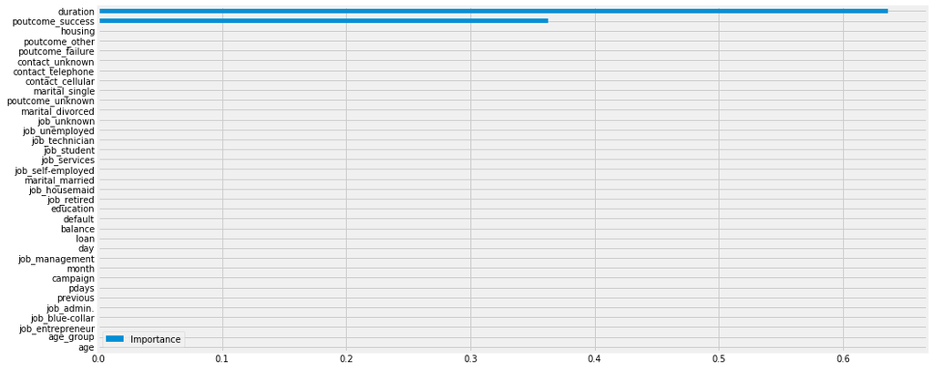

```python
print('Feature Importance for Decision Tree Classifier ', '--'*38)
feature_importances = pd.DataFrame(dt_hyper.feature_importances_, index = X.columns,
                                   columns=['Importance']).sort_values('Importance', ascending = True)
feature_importances.sort_values(by = 'Importance', ascending = True).plot(kind = 'barh', figsize = (15, 7.2))
```

#### Bagging, AdaBoost, Gradient Boosting Classifier

```python
# Bagging Classifier
bgcl = BaggingClassifier(base_estimator = DecisionTreeClassifier(max_depth = 3, random_state = random_state),
                         n_estimators = 50, random_state = random_state)
base_model = [bgcl]
n_splits = 5
df1 = train_and_predict(n_splits, base_model, X, y, 'Bagging Classifier')
df = df.append(df1)
df
```

```
Model- Bagging classifier and CV- 0
--------------------
Training Score: 0.900
Test Score: 0.898
Accuracy Score: 0.898
Precision Score - Subscribe: 0.664
Recall Score - Subscribe: 0.267
f1 Score - Subscribe: 0.381
Precision Score - Macro: 0.787
Recall Score - Macro: 0.625
f1 Score - Macro: 0.663


Model- Bagging classifier and CV- 1
--------------------
Training Score: 0.899
Test Score: 0.901
Accuracy Score: 0.901
Precision Score - Subscribe: 0.692
Recall Score - Subscribe: 0.283
f1 Score - Subscribe: 0.402
Precision Score - Macro: 0.802
Recall Score - Macro: 0.633
f1 Score - Macro: 0.674


Model- Bagging classifier and CV- 2
--------------------
Training Score: 0.900
Test Score: 0.897
Accuracy Score: 0.897
Precision Score - Subscribe: 0.630
Recall Score - Subscribe: 0.286
f1 Score - Subscribe: 0.394
Precision Score - Macro: 0.771
Recall Score - Macro: 0.632
f1 Score - Macro: 0.669


Model- Bagging classifier and CV- 3
```

[output cut: 8 more lines]

```
Recall Score - Macro: 0.626
f1 Score - Macro: 0.665


Model- Bagging classifier and CV- 4
--------------------
Training Score: 0.900
Test Score: 0.900
Accuracy Score: 0.900
Precision Score - Subscribe: 0.679
Recall Score - Subscribe: 0.270
f1 Score - Subscribe: 0.387
Precision Score - Macro: 0.795
Recall Score - Macro: 0.627
f1 Score - Macro: 0.666
```

|  | Accuracy | Precision_Subscribe | Precision_Macro | Recall_Subscribe | Recall_Macro | f1_Subscribe | f1_Macro |
| --- | --- | --- | --- | --- | --- | --- | --- |
| Baseline Model | 0.882 | 0.000 | 0.441 | 0.000 | 0.500 | 0.000 | 0.469 |
| Logistic Regression Without Hyperparameter Tuning | 0.898 | 0.623 | 0.769 | 0.326 | 0.650 | 0.428 | 0.685 |
| k-Nearest Neighbor Scaled Without Hyperparameter Tuning | 0.891 | 0.560 | 0.736 | 0.299 | 0.634 | 0.390 | 0.665 |
| k-Nearest Neighbor Scaled With Hyperparameter Tuning | 0.886 | 0.518 | 0.716 | 0.328 | 0.644 | 0.402 | 0.669 |
| Naive Bayes Classifier | 0.814 | 0.320 | 0.625 | 0.518 | 0.686 | 0.395 | 0.643 |
| Naive Bayes, Oversampled | 0.718 | 0.250 | 0.600 | 0.707 | 0.713 | 0.370 | 0.594 |
| Decision Tree Classifier | 0.874 | 0.463 | 0.696 | 0.478 | 0.702 | 0.470 | 0.699 |
| Decision Tree Classifier - Reducing Max Depth | 0.898 | 0.672 | 0.791 | 0.256 | 0.619 | 0.367 | 0.656 |
| Bagging Classifier | 0.899 | 0.668 | 0.789 | 0.275 | 0.629 | 0.390 | 0.667 |

```python
# AdaBoost Classifier
abcl = AdaBoostClassifier(n_estimators = 10, random_state = random_state)
base_model = [abcl]
n_splits = 5
df1 = train_and_predict(n_splits, base_model, X, y, 'AdaBoost Classifier')
df = df.append(df1)
df
```

```
Model- Adaboost classifier and CV- 0
--------------------
Training Score: 0.889
Test Score: 0.887
Accuracy Score: 0.887
Precision Score - Subscribe: 0.523
Recall Score - Subscribe: 0.413
f1 Score - Subscribe: 0.462
Precision Score - Macro: 0.724
Recall Score - Macro: 0.682
f1 Score - Macro: 0.699


Model- Adaboost classifier and CV- 1
--------------------
Training Score: 0.891
Test Score: 0.893
Accuracy Score: 0.893
Precision Score - Subscribe: 0.559
Recall Score - Subscribe: 0.382
f1 Score - Subscribe: 0.454
Precision Score - Macro: 0.740
Recall Score - Macro: 0.671
f1 Score - Macro: 0.697


Model- Adaboost classifier and CV- 2
--------------------
Training Score: 0.891
Test Score: 0.887
Accuracy Score: 0.887
Precision Score - Subscribe: 0.527
Recall Score - Subscribe: 0.373
f1 Score - Subscribe: 0.437
Precision Score - Macro: 0.723
Recall Score - Macro: 0.664
f1 Score - Macro: 0.687


Model- Adaboost classifier and CV- 3
```

[output cut: 8 more lines]

```
Recall Score - Macro: 0.678
f1 Score - Macro: 0.705


Model- Adaboost classifier and CV- 4
--------------------
Training Score: 0.892
Test Score: 0.889
Accuracy Score: 0.889
Precision Score - Subscribe: 0.538
Recall Score - Subscribe: 0.366
f1 Score - Subscribe: 0.435
Precision Score - Macro: 0.728
Recall Score - Macro: 0.662
f1 Score - Macro: 0.687
```

|  | Accuracy | Precision_Subscribe | Precision_Macro | Recall_Subscribe | Recall_Macro | f1_Subscribe | f1_Macro |
| --- | --- | --- | --- | --- | --- | --- | --- |
| Baseline Model | 0.882 | 0.000 | 0.441 | 0.000 | 0.500 | 0.000 | 0.469 |
| Logistic Regression Without Hyperparameter Tuning | 0.898 | 0.623 | 0.769 | 0.326 | 0.650 | 0.428 | 0.685 |
| k-Nearest Neighbor Scaled Without Hyperparameter Tuning | 0.891 | 0.560 | 0.736 | 0.299 | 0.634 | 0.390 | 0.665 |
| k-Nearest Neighbor Scaled With Hyperparameter Tuning | 0.886 | 0.518 | 0.716 | 0.328 | 0.644 | 0.402 | 0.669 |
| Naive Bayes Classifier | 0.814 | 0.320 | 0.625 | 0.518 | 0.686 | 0.395 | 0.643 |
| Naive Bayes, Oversampled | 0.718 | 0.250 | 0.600 | 0.707 | 0.713 | 0.370 | 0.594 |
| Decision Tree Classifier | 0.874 | 0.463 | 0.696 | 0.478 | 0.702 | 0.470 | 0.699 |
| Decision Tree Classifier - Reducing Max Depth | 0.898 | 0.672 | 0.791 | 0.256 | 0.619 | 0.367 | 0.656 |
| Bagging Classifier | 0.899 | 0.668 | 0.789 | 0.275 | 0.629 | 0.390 | 0.667 |
| AdaBoost Classifier | 0.890 | 0.545 | 0.733 | 0.386 | 0.671 | 0.451 | 0.695 |

```python
# Gradient Boosting Classifier
gbcl = GradientBoostingClassifier(n_estimators = 50, random_state = random_state)
base_model = [gbcl]
n_splits = 5
df1 = train_and_predict(n_splits, base_model, X, y, 'Gradient Boosting Classifier')
df = df.append(df1)
df
```

```
Model- Gradient boosting classifier and CV- 0
--------------------
Training Score: 0.903
Test Score: 0.902
Accuracy Score: 0.902
Precision Score - Subscribe: 0.668
Recall Score - Subscribe: 0.327
f1 Score - Subscribe: 0.439
Precision Score - Macro: 0.792
Recall Score - Macro: 0.653
f1 Score - Macro: 0.693


Model- Gradient boosting classifier and CV- 1
--------------------
Training Score: 0.904
Test Score: 0.903
Accuracy Score: 0.903
Precision Score - Subscribe: 0.671
Recall Score - Subscribe: 0.334
f1 Score - Subscribe: 0.446
Precision Score - Macro: 0.794
Recall Score - Macro: 0.656
f1 Score - Macro: 0.696


Model- Gradient boosting classifier and CV- 2
--------------------
Training Score: 0.905
Test Score: 0.901
Accuracy Score: 0.901
Precision Score - Subscribe: 0.660
Recall Score - Subscribe: 0.310
f1 Score - Subscribe: 0.422
Precision Score - Macro: 0.787
Recall Score - Macro: 0.644
f1 Score - Macro: 0.684


Model- Gradient boosting classifier and CV- 3
```

[output cut: 8 more lines]

```
Recall Score - Macro: 0.639
f1 Score - Macro: 0.678


Model- Gradient boosting classifier and CV- 4
--------------------
Training Score: 0.904
Test Score: 0.900
Accuracy Score: 0.900
Precision Score - Subscribe: 0.659
Recall Score - Subscribe: 0.305
f1 Score - Subscribe: 0.417
Precision Score - Macro: 0.787
Recall Score - Macro: 0.642
f1 Score - Macro: 0.681
```

|  | Accuracy | Precision_Subscribe | Precision_Macro | Recall_Subscribe | Recall_Macro | f1_Subscribe | f1_Macro |
| --- | --- | --- | --- | --- | --- | --- | --- |
| Baseline Model | 0.882 | 0.000 | 0.441 | 0.000 | 0.500 | 0.000 | 0.469 |
| Logistic Regression Without Hyperparameter Tuning | 0.898 | 0.623 | 0.769 | 0.326 | 0.650 | 0.428 | 0.685 |
| k-Nearest Neighbor Scaled Without Hyperparameter Tuning | 0.891 | 0.560 | 0.736 | 0.299 | 0.634 | 0.390 | 0.665 |
| k-Nearest Neighbor Scaled With Hyperparameter Tuning | 0.886 | 0.518 | 0.716 | 0.328 | 0.644 | 0.402 | 0.669 |
| Naive Bayes Classifier | 0.814 | 0.320 | 0.625 | 0.518 | 0.686 | 0.395 | 0.643 |
| Naive Bayes, Oversampled | 0.718 | 0.250 | 0.600 | 0.707 | 0.713 | 0.370 | 0.594 |
| Decision Tree Classifier | 0.874 | 0.463 | 0.696 | 0.478 | 0.702 | 0.470 | 0.699 |
| Decision Tree Classifier - Reducing Max Depth | 0.898 | 0.672 | 0.791 | 0.256 | 0.619 | 0.367 | 0.656 |
| Bagging Classifier | 0.899 | 0.668 | 0.789 | 0.275 | 0.629 | 0.390 | 0.667 |
| AdaBoost Classifier | 0.890 | 0.545 | 0.733 | 0.386 | 0.671 | 0.451 | 0.695 |
| Gradient Boosting Classifier | 0.901 | 0.665 | 0.790 | 0.315 | 0.647 | 0.427 | 0.686 |

```python
abcl_over = AdaBoostClassifier(n_estimators = 15, random_state = random_state, learning_rate = 0.3)
base_model = [abcl_over]
n_splits = 5
df1 = train_and_predict(n_splits, base_model, X, y, 'AdaBoost Classifier, Oversampled', oversampling = True)
df = df.append(df1)
df
```

```
Model- Adaboost classifier, oversampled and CV- 0
--------------------
Training Score: 0.848
Test Score: 0.807
Accuracy Score: 0.807
Precision Score - Subscribe: 0.354
Recall Score - Subscribe: 0.793
f1 Score - Subscribe: 0.490
Precision Score - Macro: 0.661
Recall Score - Macro: 0.801
f1 Score - Macro: 0.685


Model- Adaboost classifier, oversampled and CV- 1
--------------------
Training Score: 0.837
Test Score: 0.816
Accuracy Score: 0.816
Precision Score - Subscribe: 0.365
Recall Score - Subscribe: 0.778
f1 Score - Subscribe: 0.497
Precision Score - Macro: 0.665
Recall Score - Macro: 0.799
f1 Score - Macro: 0.692


Model- Adaboost classifier, oversampled and CV- 2
--------------------
Training Score: 0.849
Test Score: 0.808
Accuracy Score: 0.808
Precision Score - Subscribe: 0.355
Recall Score - Subscribe: 0.786
f1 Score - Subscribe: 0.489
Precision Score - Macro: 0.661
Recall Score - Macro: 0.798
f1 Score - Macro: 0.685


Model- Adaboost classifier, oversampled and CV- 3
```

[output cut: 8 more lines]

```
Recall Score - Macro: 0.816
f1 Score - Macro: 0.688


Model- Adaboost classifier, oversampled and CV- 4
--------------------
Training Score: 0.833
Test Score: 0.816
Accuracy Score: 0.816
Precision Score - Subscribe: 0.366
Recall Score - Subscribe: 0.777
f1 Score - Subscribe: 0.498
Precision Score - Macro: 0.666
Recall Score - Macro: 0.799
f1 Score - Macro: 0.693
```

|  | Accuracy | Precision_Subscribe | Precision_Macro | Recall_Subscribe | Recall_Macro | f1_Subscribe | f1_Macro |
| --- | --- | --- | --- | --- | --- | --- | --- |
| Baseline Model | 0.882 | 0.000 | 0.441 | 0.000 | 0.500 | 0.000 | 0.469 |
| Logistic Regression Without Hyperparameter Tuning | 0.898 | 0.623 | 0.769 | 0.326 | 0.650 | 0.428 | 0.685 |
| k-Nearest Neighbor Scaled Without Hyperparameter Tuning | 0.891 | 0.560 | 0.736 | 0.299 | 0.634 | 0.390 | 0.665 |
| k-Nearest Neighbor Scaled With Hyperparameter Tuning | 0.886 | 0.518 | 0.716 | 0.328 | 0.644 | 0.402 | 0.669 |
| Naive Bayes Classifier | 0.814 | 0.320 | 0.625 | 0.518 | 0.686 | 0.395 | 0.643 |
| Naive Bayes, Oversampled | 0.718 | 0.250 | 0.600 | 0.707 | 0.713 | 0.370 | 0.594 |
| Decision Tree Classifier | 0.874 | 0.463 | 0.696 | 0.478 | 0.702 | 0.470 | 0.699 |
| Decision Tree Classifier - Reducing Max Depth | 0.898 | 0.672 | 0.791 | 0.256 | 0.619 | 0.367 | 0.656 |
| Bagging Classifier | 0.899 | 0.668 | 0.789 | 0.275 | 0.629 | 0.390 | 0.667 |
| AdaBoost Classifier | 0.890 | 0.545 | 0.733 | 0.386 | 0.671 | 0.451 | 0.695 |
| Gradient Boosting Classifier | 0.901 | 0.665 | 0.790 | 0.315 | 0.647 | 0.427 | 0.686 |
| AdaBoost Classifier, Oversampled | 0.810 | 0.359 | 0.663 | 0.793 | 0.803 | 0.494 | 0.689 |

```python
# Random Forest Classifier
rfc = RandomForestClassifier(n_jobs = -1, random_state = random_state)
base_model = [rfc]
n_splits = 5
df1 = train_and_predict(n_splits, base_model, X, y, 'Random Forest Classifier')
df = df.append(df1)
df
```

```
Model- Random forest classifier and CV- 0
--------------------
Training Score: 1.000
Test Score: 0.904
Accuracy Score: 0.904
Precision Score - Subscribe: 0.672
Recall Score - Subscribe: 0.345
f1 Score - Subscribe: 0.456
Precision Score - Macro: 0.795
Recall Score - Macro: 0.661
f1 Score - Macro: 0.702


Model- Random forest classifier and CV- 1
--------------------
Training Score: 1.000
Test Score: 0.904
Accuracy Score: 0.904
Precision Score - Subscribe: 0.670
Recall Score - Subscribe: 0.349
f1 Score - Subscribe: 0.459
Precision Score - Macro: 0.794
Recall Score - Macro: 0.663
f1 Score - Macro: 0.703


Model- Random forest classifier and CV- 2
--------------------
Training Score: 1.000
Test Score: 0.901
Accuracy Score: 0.901
Precision Score - Subscribe: 0.656
Recall Score - Subscribe: 0.320
f1 Score - Subscribe: 0.430
Precision Score - Macro: 0.786
Recall Score - Macro: 0.649
f1 Score - Macro: 0.688


Model- Random forest classifier and CV- 3
```

[output cut: 8 more lines]

```
Recall Score - Macro: 0.653
f1 Score - Macro: 0.692


Model- Random forest classifier and CV- 4
--------------------
Training Score: 1.000
Test Score: 0.902
Accuracy Score: 0.902
Precision Score - Subscribe: 0.668
Recall Score - Subscribe: 0.329
f1 Score - Subscribe: 0.441
Precision Score - Macro: 0.792
Recall Score - Macro: 0.654
f1 Score - Macro: 0.694
```

|  | Accuracy | Precision_Subscribe | Precision_Macro | Recall_Subscribe | Recall_Macro | f1_Subscribe | f1_Macro |
| --- | --- | --- | --- | --- | --- | --- | --- |
| Baseline Model | 0.882 | 0.000 | 0.441 | 0.000 | 0.500 | 0.000 | 0.469 |
| Logistic Regression Without Hyperparameter Tuning | 0.898 | 0.623 | 0.769 | 0.326 | 0.650 | 0.428 | 0.685 |
| k-Nearest Neighbor Scaled Without Hyperparameter Tuning | 0.891 | 0.560 | 0.736 | 0.299 | 0.634 | 0.390 | 0.665 |
| k-Nearest Neighbor Scaled With Hyperparameter Tuning | 0.886 | 0.518 | 0.716 | 0.328 | 0.644 | 0.402 | 0.669 |
| Naive Bayes Classifier | 0.814 | 0.320 | 0.625 | 0.518 | 0.686 | 0.395 | 0.643 |
| Naive Bayes, Oversampled | 0.718 | 0.250 | 0.600 | 0.707 | 0.713 | 0.370 | 0.594 |
| Decision Tree Classifier | 0.874 | 0.463 | 0.696 | 0.478 | 0.702 | 0.470 | 0.699 |
| Decision Tree Classifier - Reducing Max Depth | 0.898 | 0.672 | 0.791 | 0.256 | 0.619 | 0.367 | 0.656 |
| Bagging Classifier | 0.899 | 0.668 | 0.789 | 0.275 | 0.629 | 0.390 | 0.667 |
| AdaBoost Classifier | 0.890 | 0.545 | 0.733 | 0.386 | 0.671 | 0.451 | 0.695 |
| Gradient Boosting Classifier | 0.901 | 0.665 | 0.790 | 0.315 | 0.647 | 0.427 | 0.686 |
| AdaBoost Classifier, Oversampled | 0.810 | 0.359 | 0.663 | 0.793 | 0.803 | 0.494 | 0.689 |
| Random Forest Classifier | 0.902 | 0.664 | 0.790 | 0.335 | 0.656 | 0.445 | 0.696 |

```python
# Random Forest Classifier with hyperparameter tuning
rfc = RandomForestClassifier(n_jobs = -1, random_state = random_state)
params = {'n_estimators' : [10, 20, 30, 50, 75, 100], 'max_depth': [1, 2, 3, 5, 7, 10]}

scoring = {'Recall': make_scorer(recall_score), 'f1_score': make_scorer(f1_score)}

skf = StratifiedKFold(n_splits = 3, shuffle = True, random_state = random_state)

rfc_grid = GridSearchCV(rfc, param_grid = params, n_jobs = -1, cv = skf, scoring = scoring, refit = 'f1_score')
rfc_grid.fit(X, y)

print(rfc_grid.best_estimator_)
print(rfc_grid.best_params_)
```

```
RandomForestClassifier(max_depth=10, n_estimators=10, n_jobs=-1,
                       random_state=44)
{'max_depth': 10, 'n_estimators': 10}
```

```python
# Random Forest Classifier with hyperparameter tuning
rfc_hyper = RandomForestClassifier(bootstrap = True, class_weight = None, criterion = 'gini', max_depth = 10,
                                   max_features = 'auto', max_leaf_nodes = None, min_impurity_decrease = 0.0,
                                   min_impurity_split = None, min_samples_leaf = 1, min_samples_split = 2,
                                   min_weight_fraction_leaf = 0.0, n_estimators = 20, n_jobs = -1,
                                   oob_score = False, random_state = 42, verbose = 0, warm_start = False)
base_model = [rfc_hyper]
n_splits = 5
df1 = train_and_predict(n_splits, base_model, X, y, 'Random Forest Classifier With Hyperparameter Tuning')
df = df.append(df1)
df
```

```
Model- Random forest classifier with hyperparameter tuning and CV- 0
--------------------
Training Score: 0.909
Test Score: 0.896
Accuracy Score: 0.896
Precision Score - Subscribe: 0.701
Recall Score - Subscribe: 0.198
f1 Score - Subscribe: 0.308
Precision Score - Macro: 0.802
Recall Score - Macro: 0.593
f1 Score - Macro: 0.626


Model- Random forest classifier with hyperparameter tuning and CV- 1
--------------------
Training Score: 0.913
Test Score: 0.900
Accuracy Score: 0.900
Precision Score - Subscribe: 0.734
Recall Score - Subscribe: 0.232
f1 Score - Subscribe: 0.352
Precision Score - Macro: 0.820
Recall Score - Macro: 0.610
f1 Score - Macro: 0.649


Model- Random forest classifier with hyperparameter tuning and CV- 2
--------------------
Training Score: 0.912
Test Score: 0.897
Accuracy Score: 0.897
Precision Score - Subscribe: 0.716
Recall Score - Subscribe: 0.200
f1 Score - Subscribe: 0.313
Precision Score - Macro: 0.810
Recall Score - Macro: 0.595
f1 Score - Macro: 0.629


Model- Random forest classifier with hyperparameter tuning and CV- 3
```

[output cut: 8 more lines]

```
Recall Score - Macro: 0.593
f1 Score - Macro: 0.626


Model- Random forest classifier with hyperparameter tuning and CV- 4
--------------------
Training Score: 0.914
Test Score: 0.899
Accuracy Score: 0.899
Precision Score - Subscribe: 0.711
Recall Score - Subscribe: 0.237
f1 Score - Subscribe: 0.356
Precision Score - Macro: 0.809
Recall Score - Macro: 0.612
f1 Score - Macro: 0.651
```

|  | Accuracy | Precision_Subscribe | Precision_Macro | Recall_Subscribe | Recall_Macro | f1_Subscribe | f1_Macro |
| --- | --- | --- | --- | --- | --- | --- | --- |
| Baseline Model | 0.882 | 0.000 | 0.441 | 0.000 | 0.500 | 0.000 | 0.469 |
| Logistic Regression Without Hyperparameter Tuning | 0.898 | 0.623 | 0.769 | 0.326 | 0.650 | 0.428 | 0.685 |
| k-Nearest Neighbor Scaled Without Hyperparameter Tuning | 0.891 | 0.560 | 0.736 | 0.299 | 0.634 | 0.390 | 0.665 |
| k-Nearest Neighbor Scaled With Hyperparameter Tuning | 0.886 | 0.518 | 0.716 | 0.328 | 0.644 | 0.402 | 0.669 |
| Naive Bayes Classifier | 0.814 | 0.320 | 0.625 | 0.518 | 0.686 | 0.395 | 0.643 |
| Naive Bayes, Oversampled | 0.718 | 0.250 | 0.600 | 0.707 | 0.713 | 0.370 | 0.594 |
| Decision Tree Classifier | 0.874 | 0.463 | 0.696 | 0.478 | 0.702 | 0.470 | 0.699 |
| Decision Tree Classifier - Reducing Max Depth | 0.898 | 0.672 | 0.791 | 0.256 | 0.619 | 0.367 | 0.656 |
| Bagging Classifier | 0.899 | 0.668 | 0.789 | 0.275 | 0.629 | 0.390 | 0.667 |
| AdaBoost Classifier | 0.890 | 0.545 | 0.733 | 0.386 | 0.671 | 0.451 | 0.695 |
| Gradient Boosting Classifier | 0.901 | 0.665 | 0.790 | 0.315 | 0.647 | 0.427 | 0.686 |
| AdaBoost Classifier, Oversampled | 0.810 | 0.359 | 0.663 | 0.793 | 0.803 | 0.494 | 0.689 |
| Random Forest Classifier | 0.902 | 0.664 | 0.790 | 0.335 | 0.656 | 0.445 | 0.696 |
| Random Forest Classifier With Hyperparameter Tuning | 0.898 | 0.714 | 0.809 | 0.213 | 0.601 | 0.328 | 0.636 |

```python
# Random Forest Classifier with hyperparameter tuning, Oversampled
rfc_over = RandomForestClassifier(bootstrap = True, class_weight = None, criterion = 'gini', max_depth = 10,
                                   max_features = 'auto', max_leaf_nodes = None, min_impurity_decrease = 0.0,
                                   min_impurity_split = None, min_samples_leaf = 1, min_samples_split = 2,
                                   min_weight_fraction_leaf = 0.0, n_estimators = 20, n_jobs = -1,
                                   oob_score = False, random_state = 42, verbose = 0, warm_start = False)
base_model = [rfc_over]
n_splits = 5
df1 = train_and_predict(n_splits, base_model, X, y,
                        'Random Forest Classifier, Oversampled With Hyperparameter Tuning',
                        oversampling = True)
df = df.append(df1)
df
```

```
Model- Random forest classifier, oversampled with hyperparameter tuning and CV- 0
--------------------
Training Score: 0.912
Test Score: 0.851
Accuracy Score: 0.851
Precision Score - Subscribe: 0.423
Recall Score - Subscribe: 0.743
f1 Score - Subscribe: 0.539
Precision Score - Macro: 0.692
Recall Score - Macro: 0.804
f1 Score - Macro: 0.725


Model- Random forest classifier, oversampled with hyperparameter tuning and CV- 1
--------------------
Training Score: 0.918
Test Score: 0.863
Accuracy Score: 0.863
Precision Score - Subscribe: 0.447
Recall Score - Subscribe: 0.739
f1 Score - Subscribe: 0.557
Precision Score - Macro: 0.705
Recall Score - Macro: 0.809
f1 Score - Macro: 0.738


Model- Random forest classifier, oversampled with hyperparameter tuning and CV- 2
--------------------
Training Score: 0.914
Test Score: 0.852
Accuracy Score: 0.852
Precision Score - Subscribe: 0.424
Recall Score - Subscribe: 0.741
f1 Score - Subscribe: 0.540
Precision Score - Macro: 0.693
Recall Score - Macro: 0.804
f1 Score - Macro: 0.726


Model- Random forest classifier, oversampled with hyperparameter tuning and CV- 3
```

[output cut: 8 more lines]

```
Recall Score - Macro: 0.810
f1 Score - Macro: 0.738


Model- Random forest classifier, oversampled with hyperparameter tuning and CV- 4
--------------------
Training Score: 0.918
Test Score: 0.857
Accuracy Score: 0.857
Precision Score - Subscribe: 0.436
Recall Score - Subscribe: 0.755
f1 Score - Subscribe: 0.553
Precision Score - Macro: 0.700
Recall Score - Macro: 0.813
f1 Score - Macro: 0.734
```

|  | Accuracy | Precision_Subscribe | Precision_Macro | Recall_Subscribe | Recall_Macro | f1_Subscribe | f1_Macro |
| --- | --- | --- | --- | --- | --- | --- | --- |
| Baseline Model | 0.882 | 0.000 | 0.441 | 0.000 | 0.500 | 0.000 | 0.469 |
| Logistic Regression Without Hyperparameter Tuning | 0.898 | 0.623 | 0.769 | 0.326 | 0.650 | 0.428 | 0.685 |
| k-Nearest Neighbor Scaled Without Hyperparameter Tuning | 0.891 | 0.560 | 0.736 | 0.299 | 0.634 | 0.390 | 0.665 |
| k-Nearest Neighbor Scaled With Hyperparameter Tuning | 0.886 | 0.518 | 0.716 | 0.328 | 0.644 | 0.402 | 0.669 |
| Naive Bayes Classifier | 0.814 | 0.320 | 0.625 | 0.518 | 0.686 | 0.395 | 0.643 |
| Naive Bayes, Oversampled | 0.718 | 0.250 | 0.600 | 0.707 | 0.713 | 0.370 | 0.594 |
| Decision Tree Classifier | 0.874 | 0.463 | 0.696 | 0.478 | 0.702 | 0.470 | 0.699 |
| Decision Tree Classifier - Reducing Max Depth | 0.898 | 0.672 | 0.791 | 0.256 | 0.619 | 0.367 | 0.656 |
| Bagging Classifier | 0.899 | 0.668 | 0.789 | 0.275 | 0.629 | 0.390 | 0.667 |
| AdaBoost Classifier | 0.890 | 0.545 | 0.733 | 0.386 | 0.671 | 0.451 | 0.695 |
| Gradient Boosting Classifier | 0.901 | 0.665 | 0.790 | 0.315 | 0.647 | 0.427 | 0.686 |
| AdaBoost Classifier, Oversampled | 0.810 | 0.359 | 0.663 | 0.793 | 0.803 | 0.494 | 0.689 |
| Random Forest Classifier | 0.902 | 0.664 | 0.790 | 0.335 | 0.656 | 0.445 | 0.696 |
| Random Forest Classifier With Hyperparameter Tuning | 0.898 | 0.714 | 0.809 | 0.213 | 0.601 | 0.328 | 0.636 |
| Random Forest Classifier, Oversampled With Hyperparameter Tuning | 0.857 | 0.435 | 0.699 | 0.744 | 0.808 | 0.549 | 0.732 |

```python
# Random Forest Classifier with hyperparameter tuning, Oversampled -- Reducing Max Depth
rfc_over = RandomForestClassifier(bootstrap = True, class_weight = None, criterion = 'gini', max_depth = 3,
                                   max_features = 'auto', max_leaf_nodes = None, min_impurity_decrease = 0.0,
                                   min_impurity_split = None, min_samples_leaf = 1, min_samples_split = 2,
                                   min_weight_fraction_leaf = 0.0, n_estimators = 50, n_jobs = -1,
                                   oob_score = False, random_state = 42, verbose = 0, warm_start = False)
base_model = [rfc_over]
n_splits = 5
df1 = train_and_predict(n_splits, base_model, X, y,
                        'Random Forest Classifier, Oversampled With Hyperparameter Tuning - Reducing Max Depth',
                        oversampling = True)
df = df.append(df1)
df
```

```
Model- Random forest classifier, oversampled with hyperparameter tuning - reducing max depth and CV- 0
--------------------
Training Score: 0.850
Test Score: 0.801
Accuracy Score: 0.801
Precision Score - Subscribe: 0.346
Recall Score - Subscribe: 0.784
f1 Score - Subscribe: 0.480
Precision Score - Macro: 0.656
Recall Score - Macro: 0.794
f1 Score - Macro: 0.679


Model- Random forest classifier, oversampled with hyperparameter tuning - reducing max depth and CV- 1
--------------------
Training Score: 0.849
Test Score: 0.820
Accuracy Score: 0.820
Precision Score - Subscribe: 0.374
Recall Score - Subscribe: 0.795
f1 Score - Subscribe: 0.508
Precision Score - Macro: 0.671
Recall Score - Macro: 0.809
f1 Score - Macro: 0.699


Model- Random forest classifier, oversampled with hyperparameter tuning - reducing max depth and CV- 2
--------------------
Training Score: 0.848
Test Score: 0.812
Accuracy Score: 0.812
Precision Score - Subscribe: 0.361
Recall Score - Subscribe: 0.782
f1 Score - Subscribe: 0.494
Precision Score - Macro: 0.663
Recall Score - Macro: 0.799
f1 Score - Macro: 0.689


Model- Random forest classifier, oversampled with hyperparameter tuning - reducing max depth and CV- 3
```

[output cut: 8 more lines]

```
Recall Score - Macro: 0.817
f1 Score - Macro: 0.701


Model- Random forest classifier, oversampled with hyperparameter tuning - reducing max depth and CV- 4
--------------------
Training Score: 0.846
Test Score: 0.814
Accuracy Score: 0.814
Precision Score - Subscribe: 0.364
Recall Score - Subscribe: 0.794
f1 Score - Subscribe: 0.499
Precision Score - Macro: 0.666
Recall Score - Macro: 0.805
f1 Score - Macro: 0.692
```

|  | Accuracy | Precision_Subscribe | Precision_Macro | Recall_Subscribe | Recall_Macro | f1_Subscribe | f1_Macro |
| --- | --- | --- | --- | --- | --- | --- | --- |
| Baseline Model | 0.882 | 0.000 | 0.441 | 0.000 | 0.500 | 0.000 | 0.469 |
| Logistic Regression Without Hyperparameter Tuning | 0.898 | 0.623 | 0.769 | 0.326 | 0.650 | 0.428 | 0.685 |
| k-Nearest Neighbor Scaled Without Hyperparameter Tuning | 0.891 | 0.560 | 0.736 | 0.299 | 0.634 | 0.390 | 0.665 |
| k-Nearest Neighbor Scaled With Hyperparameter Tuning | 0.886 | 0.518 | 0.716 | 0.328 | 0.644 | 0.402 | 0.669 |
| Naive Bayes Classifier | 0.814 | 0.320 | 0.625 | 0.518 | 0.686 | 0.395 | 0.643 |
| Naive Bayes, Oversampled | 0.718 | 0.250 | 0.600 | 0.707 | 0.713 | 0.370 | 0.594 |
| Decision Tree Classifier | 0.874 | 0.463 | 0.696 | 0.478 | 0.702 | 0.470 | 0.699 |
| Decision Tree Classifier - Reducing Max Depth | 0.898 | 0.672 | 0.791 | 0.256 | 0.619 | 0.367 | 0.656 |
| Bagging Classifier | 0.899 | 0.668 | 0.789 | 0.275 | 0.629 | 0.390 | 0.667 |
| AdaBoost Classifier | 0.890 | 0.545 | 0.733 | 0.386 | 0.671 | 0.451 | 0.695 |
| Gradient Boosting Classifier | 0.901 | 0.665 | 0.790 | 0.315 | 0.647 | 0.427 | 0.686 |
| AdaBoost Classifier, Oversampled | 0.810 | 0.359 | 0.663 | 0.793 | 0.803 | 0.494 | 0.689 |
| Random Forest Classifier | 0.902 | 0.664 | 0.790 | 0.335 | 0.656 | 0.445 | 0.696 |
| Random Forest Classifier With Hyperparameter Tuning | 0.898 | 0.714 | 0.809 | 0.213 | 0.601 | 0.328 | 0.636 |
| Random Forest Classifier, Oversampled With Hyperparameter Tuning | 0.857 | 0.435 | 0.699 | 0.744 | 0.808 | 0.549 | 0.732 |
| Random Forest Classifier, Oversampled With Hyperparameter Tuning - Reducing Max Depth | 0.813 | 0.364 | 0.666 | 0.794 | 0.805 | 0.499 | 0.692 |

```python
rfc_over = RandomForestClassifier(bootstrap = True, class_weight = None, criterion = 'gini', max_depth = 3,
                                   max_features = 'auto', max_leaf_nodes = None, min_impurity_decrease = 0.0,
                                   min_impurity_split = None, min_samples_leaf = 1, min_samples_split = 2,
                                   min_weight_fraction_leaf = 0.0, n_estimators = 50, n_jobs = -1,
                                   oob_score = False, random_state = 42, verbose = 0, warm_start = False)
rfc_over.fit(X, y)

random_forest_tree = open('random_forest.dot','w')
dot_data = export_graphviz(rfc_over.estimators_[0], out_file = random_forest_tree, feature_names = list(X_train), class_names = ['No', 'Yes'], rounded = True, proportion = False, filled = True)
random_forest_tree.close()

retCode = system("dot -Tpng random_forest.dot -o random_forest.png")
if(retCode>0):
    print("system command returning error: "+str(retCode))
else:
    display(Image("random_forest.png"))
```

```
system command returning error: 32512
```

```
Feature Importance for Random Forest Classifier  ----------------------------------------------------------------------------
```

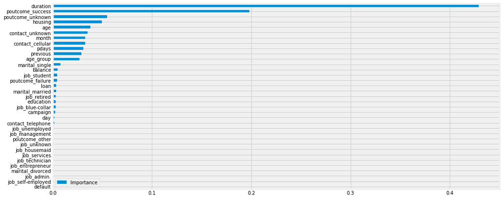

```python
print('Feature Importance for Random Forest Classifier ', '--'*38)
feature_importances = pd.DataFrame(rfc_over.feature_importances_, index = X.columns,
                                   columns=['Importance']).sort_values('Importance', ascending = True)
feature_importances.sort_values(by = 'Importance', ascending = True).plot(kind = 'barh', figsize = (15, 7.2))
```

### Comparing model results

```python
print('Conditional Formatting on the scores dataframe ', '--'*39)
display(df.style.background_gradient(cmap = sns.light_palette('green', as_cmap = True)))
```

```
Conditional Formatting on the scores dataframe  ------------------------------------------------------------------------------
```

|  | Accuracy | Precision_Subscribe | Precision_Macro | Recall_Subscribe | Recall_Macro | f1_Subscribe | f1_Macro |
| --- | --- | --- | --- | --- | --- | --- | --- |
| Baseline Model | 0.882 | 0 | 0.441 | 0 | 0.5 | 0 | 0.469 |
| Logistic Regression Without Hyperparameter Tuning | 0.898 | 0.623 | 0.769 | 0.326 | 0.65 | 0.428 | 0.685 |
| k-Nearest Neighbor Scaled Without Hyperparameter Tuning | 0.891 | 0.56 | 0.736 | 0.299 | 0.634 | 0.39 | 0.665 |
| k-Nearest Neighbor Scaled With Hyperparameter Tuning | 0.886 | 0.518 | 0.716 | 0.328 | 0.644 | 0.402 | 0.669 |
| Naive Bayes Classifier | 0.814 | 0.32 | 0.625 | 0.518 | 0.686 | 0.395 | 0.643 |
| Naive Bayes, Oversampled | 0.718 | 0.25 | 0.6 | 0.707 | 0.713 | 0.37 | 0.594 |
| Decision Tree Classifier | 0.874 | 0.463 | 0.696 | 0.478 | 0.702 | 0.47 | 0.699 |
| Decision Tree Classifier - Reducing Max Depth | 0.898 | 0.672 | 0.791 | 0.256 | 0.619 | 0.367 | 0.656 |
| Bagging Classifier | 0.899 | 0.668 | 0.789 | 0.275 | 0.629 | 0.39 | 0.667 |
| AdaBoost Classifier | 0.89 | 0.545 | 0.733 | 0.386 | 0.671 | 0.451 | 0.695 |
| Gradient Boosting Classifier | 0.901 | 0.665 | 0.79 | 0.315 | 0.647 | 0.427 | 0.686 |
| AdaBoost Classifier, Oversampled | 0.81 | 0.359 | 0.663 | 0.793 | 0.803 | 0.494 | 0.689 |
| Random Forest Classifier | 0.902 | 0.664 | 0.79 | 0.335 | 0.656 | 0.445 | 0.696 |
| Random Forest Classifier With Hyperparameter Tuning | 0.898 | 0.714 | 0.809 | 0.213 | 0.601 | 0.328 | 0.636 |
| Random Forest Classifier, Oversampled With Hyperparameter Tuning | 0.857 | 0.435 | 0.699 | 0.744 | 0.808 | 0.549 | 0.732 |
| Random Forest Classifier, Oversampled With Hyperparameter Tuning - Reducing Max Depth | 0.813 | 0.364 | 0.666 | 0.794 | 0.805 | 0.499 | 0.692 |

### Conclusion

The classification goal is to predict if the client will subscribe (yes/no) a term deposit.

Most of the ML models works best when the number of classes are in equal proportion since they are designed to maximize accuracy and reduce error. Thus, they do not take into account the class distribution / proportion or balance of classes. In our dataset, the clients subscribing to term deposit (class 'yes' i.e. 1) is 11.7% whereas those about 88.3% of the clients didn't subscribe (class 'no' i.e. 0) to the term deposit.

Building a DummyClassifier, baseline model, in our case gave an accuracy of 88.2% with zero recall and precision for predicting minority class i.e. where the client subscribed to term deposits. In this cases, important performance measures such as precision, recall, and f1-score would be helpful. We can also calculate this metrics for the minority, positive, class.

- **Precision**: When it predicts the positive result, how often is it correct? i.e. limit the number of false positives.
- **Recall**: When it is actually the positive result, how often does it predict correctly? i.e. limit the number of false negatives.
- **f1-score**: Harmonic mean of precision and recall.

The confusion matrix for class 1 (Subscribed) would look like:

|  | Predicted: 0 (Not Subscribed) | Predicted: 1 (Subscribed) |
| --- | --- | --- |
| **Actual: 0 (Not Subscribed)** | True Negatives | False Positives |
| **Actual: 1 (Subscribed)** | False Negatives | True Positives |

- **Precision would tell us cases where actually the client hadn't subscribed to the term deposit but we predicted it as subscribed.**
- **Recall would tell us cases where actually the client had subscribed to the term deposit but we predicted it as didn't subscribe.**

In our case, it would be recall that would hold more importance then precision. So choosing recall particularly for class 1 and accuracy as as evaluation metric. Also important would be how is model behaving over the training and test scores across the cross validation sets.

**Modeling** was sub-divided in two phases, in the first phase we applied standard models (with and without the hyperparameter tuning wherever applicable) such as Logistic Regression, k-Nearest Neighbor and Naive Bayes classifiers. In second phase apply ensemble techniques such as Decision Tree, Bagging, AdaBoost, Gradient Boosting and Random Forest classifiers. Oversampling the ones with higher accuracy and better recall for subscribe.

**Oversampling**, which is one of common ways to tackle the issue of imbalanced data. Over-sampling refers to various methods that aim to increase the number of instances from the underrepresented class in the data set. Out of the various methods, we chose Synthetic Minority Over-Sampling Technique (SMOTE). SMOTE’s main advantage compared to traditional random naive over-sampling is that by creating synthetic observations instead of reusing existing observations, classifier is less likely to overfit.